# Project: Analyzing Trends in Gun Sales Data across the U.S.

- Introduction
- Data Wrangling
- Exploratory Data Analysis
- Conclusions

## Introduction

The data comes from the FBI's National Instant Criminal Background Check System. The NICS is used by to determine whether a prospective buyer is eligible to buy firearms or explosives. Gun shops call into this system to ensure that each customer does not have a criminal record or isn’t otherwise ineligible to make a purchase. The data has been supplemented with state level data from census.gov.

`Mandated by the Brady Handgun Violence Prevention Act of 1993 and launched by the FBI on November 30, 1998, NICS is used by Federal Firearms Licensees (FFLs) to instantly determine whether a prospective buyer is eligible to buy firearms or explosives. Before ringing up the sale, cashiers call in a check to the FBI or to other designated agencies to ensure that each customer does not have a criminal record or isn’t otherwise ineligible to make a purchase. More than 100 million such checks have been made in the last decade, leading to more than 700,000 denials.`

These statistics represent the number of firearm background checks initiated through the NICS. They do not represent the number of firearms sold. According to The Trace, 2015: The FBI’s background check numbers come with caveats: As seen in the late February-early March 2014 bubble, many checks are for concealed carry permits, not actual gun sales. Kentucky runs a new check on each concealed carry license holder each month. And of course, the FBI’s numbers don’t include private gun sales, many of which do not require a background check. Despite those vagaries, the FBI’s NICS numbers are widely accepted as **the best proxy for total gun sales** in a given time period.

In 2015, New York Times ran a similar analysis with the data and estimated sales from background checks with a method suggested by a researcher.  
According to them: `To convert background checks into estimated sales, we relied on a method suggested in the Small Arms Survey by Jurgen Brauer, a professor at Georgia Regents University. Each long gun and handgun check was counted as 1.1 sales. Each multiple-gun check was counted as two sales. Permit checks and other types of checks were omitted. The multiplier is an estimate based on Mr. Brauer's interviews with gun shop owners.`

This is the method I applied in this analysis.

- month (monthly data from November 1998 to September 2017)
- state (55 U.S. states and offshore territories)
- handgun (number of check calls)
- long-gun (number of check calls)
- multiple (number of check calls)

The census data is a wide-table format data with 66 variables measuring quantities for 50 U.S. states. I have selected only 18 variables that I deem relevant to this analysis. The starred variables are just a few of the variables that are present in the raw data that I will not include in this analysis.

| s/n | Variable |
| --- | --- |
| 1 | Population estimates, July 1, 2016, (V2016) |
| 2 | Persons under 18 years, percent, July 1, 2016, (V2016) |
| 3 | Persons 65 years and over, percent, July 1, 2016,(V2016) |
| 4 | Female persons, percent, July 1, 2016, (V2016) |
| 5 | White alone, percent, July 1, 2016, (V2016) |
| 6 | Black or African American alone, percent, July 1, 2016, (V2016) |
| 7 | Asian alone, percent, July 1, 2016, (V2016) |
| 8 | Median value of owner-occupied housing units, 2011-2015 |
| 9 | Median gross rent, 2011-2015 |
| 10 | Persons per household, 2011-2015 |
| 11 | High school graduate or higher, percent of persons age 25 years+, 2011-2015 |
| 12 | Bachelor\'s degree or higher, percent of persons age 25 years+, 2011-2015 |
| 13 | Persons without health insurance, under age 65 years, percent |
| 14 | Median household income (in 2015 dollars), 2011-2015 |
| 15 | Per capita income in past 12 months (in 2015 dollars), 2011-2015 |
| 16 | Persons in poverty, percent |
| 17 | All firms, 2012 |
| * | Persons under 5 years, percent, July 1, 2016, (V2016) |
| * | Minority-owned firms, 2012 |
| * | Population per square mile, 2010 |
| * | Total employer establishments, 2015 |
| * | Total employment, 2015 |
| * | Total annual payroll, 2015 ($1,000) |
| * | Total employment, percent change, 2014-2015 |
| * | Total nonemployer establishments, 2015 |

The 18th variable is state but in the raw data, it would have to be created by transposing the dataframe. The starred variables are just some of the ones I deem irrelevant

## Research Questions

*In this analysis, I will answer the following research questions*:

> - *How many guns were sold in the U.S. in selected years?*
> - *What kind of gun was bought the most in those years?*
> - *What are the overall monthly trends of gun purchases in those years?*
> - *What are the top 5 states in terms of gun purchases in the U.S. in those years?*
> - *What are the most bought gun types in those states?*
> - *What kind of gun was bought the most in one of those states?*
> - *What are the overall monthly trends of gun purchases in those states?*
> - *Which states had the highest growth in gun sales over the span of a decade?*

## Data Wrangling

### General Properties

*Loading and inspecting the census data*

```python
# Importing packages.
import pandas as pd, numpy as np
import matplotlib.pyplot as plt, seaborn as sns
#% matplotlib inline

df_census_raw = pd.read_csv('Database_Ncis_and_Census_data/US_Census_Data.csv')
df_census_raw.head()
```

|  | Fact | Fact Note | Alabama | Alaska | Arizona | Arkansas | California | Colorado | Connecticut | Delaware | ... | South Dakota | Tennessee | Texas | Utah | Vermont | Virginia | Washington | West Virginia | Wisconsin | Wyoming |
| --- | --- | --- | --- | --- | --- | --- | --- | --- | --- | --- | --- | --- | --- | --- | --- | --- | --- | --- | --- | --- | --- |
| 0 | Population estimates, July 1, 2016, (V2016) | NaN | 4,863,300 | 741,894 | 6,931,071 | 2,988,248 | 39,250,017 | 5,540,545 | 3,576,452 | 952,065 | ... | 865454 | 6651194 | 27,862,596 | 3,051,217 | 624,594 | 8,411,808 | 7,288,000 | 1,831,102 | 5,778,708 | 585,501 |
| 1 | Population estimates base, April 1, 2010, (V2... | NaN | 4,780,131 | 710,249 | 6,392,301 | 2,916,025 | 37,254,522 | 5,029,324 | 3,574,114 | 897,936 | ... | 814195 | 6346298 | 25,146,100 | 2,763,888 | 625,741 | 8,001,041 | 6,724,545 | 1,853,011 | 5,687,289 | 563,767 |
| 2 | Population, percent change - April 1, 2010 (es... | NaN | 1.70% | 4.50% | 8.40% | 2.50% | 5.40% | 10.20% | 0.10% | 6.00% | ... | 0.063 | 0.048 | 10.80% | 10.40% | -0.20% | 5.10% | 8.40% | -1.20% | 1.60% | 3.90% |
| 3 | Population, Census, April 1, 2010 | NaN | 4,779,736 | 710,231 | 6,392,017 | 2,915,918 | 37,253,956 | 5,029,196 | 3,574,097 | 897,934 | ... | 814180 | 6346105 | 25,145,561 | 2,763,885 | 625,741 | 8,001,024 | 6,724,540 | 1,852,994 | 5,686,986 | 563,626 |
| 4 | Persons under 5 years, percent, July 1, 2016, ... | NaN | 6.00% | 7.30% | 6.30% | 6.40% | 6.30% | 6.10% | 5.20% | 5.80% | ... | 0.071 | 0.061 | 7.20% | 8.30% | 4.90% | 6.10% | 6.20% | 5.50% | 5.80% | 6.50% |

5 rows × 52 columns

```python
# shape of the dataframe
df_census_raw.shape
```

```
(85, 52)
```

```python
# viewing all columns in the dataframe
df_census_raw.columns
```

```
Index(['Fact', 'Fact Note', 'Alabama', 'Alaska', 'Arizona', 'Arkansas',
       'California', 'Colorado', 'Connecticut', 'Delaware', 'Florida',
       'Georgia', 'Hawaii', 'Idaho', 'Illinois', 'Indiana', 'Iowa', 'Kansas',
       'Kentucky', 'Louisiana', 'Maine', 'Maryland', 'Massachusetts',
       'Michigan', 'Minnesota', 'Mississippi', 'Missouri', 'Montana',
       'Nebraska', 'Nevada', 'New Hampshire', 'New Jersey', 'New Mexico',
       'New York', 'North Carolina', 'North Dakota', 'Ohio', 'Oklahoma',
       'Oregon', 'Pennsylvania', 'Rhode Island', 'South Carolina',
       'South Dakota', 'Tennessee', 'Texas', 'Utah', 'Vermont', 'Virginia',
       'Washington', 'West Virginia', 'Wisconsin', 'Wyoming'],
      dtype='object')
```

### Dropping Irrelevant Columns

*In this section, I will drop all irrelevant columns from the census dataset, reshape the dataframe and then rename columns for clarity*

```python
# dropping the 'Fact Note' column
df_census_raw.drop('Fact Note', axis=1, inplace=True)
df_census_raw.head()
```

|  | Fact | Alabama | Alaska | Arizona | Arkansas | California | Colorado | Connecticut | Delaware | Florida | ... | South Dakota | Tennessee | Texas | Utah | Vermont | Virginia | Washington | West Virginia | Wisconsin | Wyoming |
| --- | --- | --- | --- | --- | --- | --- | --- | --- | --- | --- | --- | --- | --- | --- | --- | --- | --- | --- | --- | --- | --- |
| 0 | Population estimates, July 1, 2016, (V2016) | 4,863,300 | 741,894 | 6,931,071 | 2,988,248 | 39,250,017 | 5,540,545 | 3,576,452 | 952,065 | 20,612,439 | ... | 865454 | 6651194 | 27,862,596 | 3,051,217 | 624,594 | 8,411,808 | 7,288,000 | 1,831,102 | 5,778,708 | 585,501 |
| 1 | Population estimates base, April 1, 2010, (V2... | 4,780,131 | 710,249 | 6,392,301 | 2,916,025 | 37,254,522 | 5,029,324 | 3,574,114 | 897,936 | 18,804,592 | ... | 814195 | 6346298 | 25,146,100 | 2,763,888 | 625,741 | 8,001,041 | 6,724,545 | 1,853,011 | 5,687,289 | 563,767 |
| 2 | Population, percent change - April 1, 2010 (es... | 1.70% | 4.50% | 8.40% | 2.50% | 5.40% | 10.20% | 0.10% | 6.00% | 9.60% | ... | 0.063 | 0.048 | 10.80% | 10.40% | -0.20% | 5.10% | 8.40% | -1.20% | 1.60% | 3.90% |
| 3 | Population, Census, April 1, 2010 | 4,779,736 | 710,231 | 6,392,017 | 2,915,918 | 37,253,956 | 5,029,196 | 3,574,097 | 897,934 | 18,801,310 | ... | 814180 | 6346105 | 25,145,561 | 2,763,885 | 625,741 | 8,001,024 | 6,724,540 | 1,852,994 | 5,686,986 | 563,626 |
| 4 | Persons under 5 years, percent, July 1, 2016, ... | 6.00% | 7.30% | 6.30% | 6.40% | 6.30% | 6.10% | 5.20% | 5.80% | 5.50% | ... | 0.071 | 0.061 | 7.20% | 8.30% | 4.90% | 6.10% | 6.20% | 5.50% | 5.80% | 6.50% |

5 rows × 51 columns

```python
# reshaping the dataframe
df_T = df_census_raw.transpose(copy=False)
```

```python
# observing the result
df_T.head()
```

|  | 0 | 1 | 2 | 3 | 4 | 5 | 6 | 7 | 8 | 9 | ... | 75 | 76 | 77 | 78 | 79 | 80 | 81 | 82 | 83 | 84 |
| --- | --- | --- | --- | --- | --- | --- | --- | --- | --- | --- | --- | --- | --- | --- | --- | --- | --- | --- | --- | --- | --- |
| Fact | Population estimates, July 1, 2016, (V2016) | Population estimates base, April 1, 2010, (V2... | Population, percent change - April 1, 2010 (es... | Population, Census, April 1, 2010 | Persons under 5 years, percent, July 1, 2016, ... | Persons under 5 years, percent, April 1, 2010 | Persons under 18 years, percent, July 1, 2016,... | Persons under 18 years, percent, April 1, 2010 | Persons 65 years and over, percent, July 1, 2... | Persons 65 years and over, percent, April 1, 2010 | ... | NaN | Value Flags | - | D | F | FN | NaN | S | X | Z |
| Alabama | 4,863,300 | 4,780,131 | 1.70% | 4,779,736 | 6.00% | 6.40% | 22.60% | 23.70% | 16.10% | 13.80% | ... | NaN | NaN | NaN | NaN | NaN | NaN | NaN | NaN | NaN | NaN |
| Alaska | 741,894 | 710,249 | 4.50% | 710,231 | 7.30% | 7.60% | 25.20% | 26.40% | 10.40% | 7.70% | ... | NaN | NaN | NaN | NaN | NaN | NaN | NaN | NaN | NaN | NaN |
| Arizona | 6,931,071 | 6,392,301 | 8.40% | 6,392,017 | 6.30% | 7.10% | 23.50% | 25.50% | 16.90% | 13.80% | ... | NaN | NaN | NaN | NaN | NaN | NaN | NaN | NaN | NaN | NaN |
| Arkansas | 2,988,248 | 2,916,025 | 2.50% | 2,915,918 | 6.40% | 6.80% | 23.60% | 24.40% | 16.30% | 14.40% | ... | NaN | NaN | NaN | NaN | NaN | NaN | NaN | NaN | NaN | NaN |

5 rows × 85 columns

```python
# checking out the new shape
df_T.shape
```

```
(51, 85)
```

```python
# selecting the columns of interest
df_T = df_T.iloc[:, 0:65]
df_T.head()
```

|  | 0 | 1 | 2 | 3 | 4 | 5 | 6 | 7 | 8 | 9 | ... | 55 | 56 | 57 | 58 | 59 | 60 | 61 | 62 | 63 | 64 |
| --- | --- | --- | --- | --- | --- | --- | --- | --- | --- | --- | --- | --- | --- | --- | --- | --- | --- | --- | --- | --- | --- |
| Fact | Population estimates, July 1, 2016, (V2016) | Population estimates base, April 1, 2010, (V2... | Population, percent change - April 1, 2010 (es... | Population, Census, April 1, 2010 | Persons under 5 years, percent, July 1, 2016, ... | Persons under 5 years, percent, April 1, 2010 | Persons under 18 years, percent, July 1, 2016,... | Persons under 18 years, percent, April 1, 2010 | Persons 65 years and over, percent, July 1, 2... | Persons 65 years and over, percent, April 1, 2010 | ... | All firms, 2012 | Men-owned firms, 2012 | Women-owned firms, 2012 | Minority-owned firms, 2012 | Nonminority-owned firms, 2012 | Veteran-owned firms, 2012 | Nonveteran-owned firms, 2012 | Population per square mile, 2010 | Land area in square miles, 2010 | FIPS Code |
| Alabama | 4,863,300 | 4,780,131 | 1.70% | 4,779,736 | 6.00% | 6.40% | 22.60% | 23.70% | 16.10% | 13.80% | ... | 374,153 | 203,604 | 137,630 | 92,219 | 272,651 | 41,943 | 316,984 | 94.4 | 50,645.33 | "01" |
| Alaska | 741,894 | 710,249 | 4.50% | 710,231 | 7.30% | 7.60% | 25.20% | 26.40% | 10.40% | 7.70% | ... | 68,032 | 35,402 | 22,141 | 13,688 | 51,147 | 7,953 | 56,091 | 1.2 | 570,640.95 | "02" |
| Arizona | 6,931,071 | 6,392,301 | 8.40% | 6,392,017 | 6.30% | 7.10% | 23.50% | 25.50% | 16.90% | 13.80% | ... | 499,926 | 245,243 | 182,425 | 135,313 | 344,981 | 46,780 | 427,582 | 56.3 | 113,594.08 | "04" |
| Arkansas | 2,988,248 | 2,916,025 | 2.50% | 2,915,918 | 6.40% | 6.80% | 23.60% | 24.40% | 16.30% | 14.40% | ... | 231,959 | 123,158 | 75,962 | 35,982 | 189,029 | 25,915 | 192,988 | 56 | 52,035.48 | "05" |

5 rows × 65 columns

```python
# giving the appropriate column labels
columns = df_T.iloc[0, :]

df_T.rename(columns=columns, inplace = True)
df_T
```

|  | Population estimates, July 1, 2016, (V2016) | Population estimates base, April 1, 2010, (V2016) | Population, percent change - April 1, 2010 (estimates base) to July 1, 2016, (V2016) | Population, Census, April 1, 2010 | Persons under 5 years, percent, July 1, 2016, (V2016) | Persons under 5 years, percent, April 1, 2010 | Persons under 18 years, percent, July 1, 2016, (V2016) | Persons under 18 years, percent, April 1, 2010 | Persons 65 years and over, percent, July 1, 2016, (V2016) | Persons 65 years and over, percent, April 1, 2010 | ... | All firms, 2012 | Men-owned firms, 2012 | Women-owned firms, 2012 | Minority-owned firms, 2012 | Nonminority-owned firms, 2012 | Veteran-owned firms, 2012 | Nonveteran-owned firms, 2012 | Population per square mile, 2010 | Land area in square miles, 2010 | FIPS Code |
| --- | --- | --- | --- | --- | --- | --- | --- | --- | --- | --- | --- | --- | --- | --- | --- | --- | --- | --- | --- | --- | --- |
| Fact | Population estimates, July 1, 2016, (V2016) | Population estimates base, April 1, 2010, (V2... | Population, percent change - April 1, 2010 (es... | Population, Census, April 1, 2010 | Persons under 5 years, percent, July 1, 2016, ... | Persons under 5 years, percent, April 1, 2010 | Persons under 18 years, percent, July 1, 2016,... | Persons under 18 years, percent, April 1, 2010 | Persons 65 years and over, percent, July 1, 2... | Persons 65 years and over, percent, April 1, 2010 | ... | All firms, 2012 | Men-owned firms, 2012 | Women-owned firms, 2012 | Minority-owned firms, 2012 | Nonminority-owned firms, 2012 | Veteran-owned firms, 2012 | Nonveteran-owned firms, 2012 | Population per square mile, 2010 | Land area in square miles, 2010 | FIPS Code |
| Alabama | 4,863,300 | 4,780,131 | 1.70% | 4,779,736 | 6.00% | 6.40% | 22.60% | 23.70% | 16.10% | 13.80% | ... | 374,153 | 203,604 | 137,630 | 92,219 | 272,651 | 41,943 | 316,984 | 94.4 | 50,645.33 | "01" |
| Alaska | 741,894 | 710,249 | 4.50% | 710,231 | 7.30% | 7.60% | 25.20% | 26.40% | 10.40% | 7.70% | ... | 68,032 | 35,402 | 22,141 | 13,688 | 51,147 | 7,953 | 56,091 | 1.2 | 570,640.95 | "02" |
| Arizona | 6,931,071 | 6,392,301 | 8.40% | 6,392,017 | 6.30% | 7.10% | 23.50% | 25.50% | 16.90% | 13.80% | ... | 499,926 | 245,243 | 182,425 | 135,313 | 344,981 | 46,780 | 427,582 | 56.3 | 113,594.08 | "04" |
| Arkansas | 2,988,248 | 2,916,025 | 2.50% | 2,915,918 | 6.40% | 6.80% | 23.60% | 24.40% | 16.30% | 14.40% | ... | 231,959 | 123,158 | 75,962 | 35,982 | 189,029 | 25,915 | 192,988 | 56 | 52,035.48 | "05" |
| California | 39,250,017 | 37,254,522 | 5.40% | 37,253,956 | 6.30% | 6.80% | 23.20% | 25.00% | 13.60% | 11.40% | ... | 3,548,449 | 1,852,580 | 1,320,085 | 1,619,857 | 1,819,107 | 252,377 | 3,176,341 | 239.1 | 155,779.22 | "06" |
| Colorado | 5,540,545 | 5,029,324 | 10.20% | 5,029,196 | 6.10% | 6.80% | 22.80% | 24.40% | 13.40% | 10.90% | ... | 547,352 | 284,554 | 194,508 | 85,849 | 442,365 | 51,722 | 469,524 | 48.5 | 103,641.89 | "08" |
| Connecticut | 3,576,452 | 3,574,114 | 0.10% | 3,574,097 | 5.20% | 5.70% | 21.10% | 22.90% | 16.10% | 14.20% | ... | 326,693 | 187,845 | 106,678 | 56,113 | 259,614 | 31,056 | 281,182 | 738.1 | 4,842.36 | "09" |
| Delaware | 952,065 | 897,936 | 6.00% | 897,934 | 5.80% | 6.20% | 21.50% | 22.90% | 17.50% | 14.40% | ... | 73,418 | 38,328 | 23,964 | 14,440 | 54,782 | 7,206 | 60,318 | 460.8 | 1,948.54 | "10" |
| Florida | 20,612,439 | 18,804,592 | 9.60% | 18,801,310 | 5.50% | 5.70% | 20.10% | 21.30% | 19.90% | 17.30% | ... | 2,100,187 | 1,084,885 | 807,817 | 926,112 | 1,121,749 | 185,756 | 1,846,686 | 350.6 | 53,624.76 | "12" |
| Georgia | 10,310,371 | 9,688,680 | 6.40% | 9,687,653 | 6.40% | 7.10% | 24.40% | 25.70% | 13.10% | 10.70% | ... | 929,864 | 480,578 | 376,506 | 371,588 | 538,893 | 96,787 | 800,585 | 168.4 | 57,513.49 | "13" |
| Hawaii | 1,428,557 | 1,360,301 | 5.00% | 1,360,301 | 6.40% | 6.40% | 21.60% | 22.30% | 17.10% | 14.30% | ... | 118,454 | 60,409 | 44,453 | 74,208 | 38,510 | 11,148 | 101,334 | 211.8 | 6,422.63 | "15" |
| Idaho | 1,683,140 | 1,567,650 | 7.40% | 1,567,582 | 6.80% | 7.80% | 26.00% | 27.40% | 15.10% | 12.40% | ... | 146,642 | 70,438 | 45,121 | 10,592 | 130,973 | 12,804 | 124,314 | 19 | 82,643.12 | "16" |
| Illinois | 12,801,539 | 12,831,574 | -0.20% | 12,830,632 | 6.00% | 6.50% | 22.90% | 24.40% | 14.60% | 12.50% | ... | 1,135,017 | 609,648 | 417,500 | 311,684 | 795,129 | 89,110 | 1,006,885 | 231.1 | 55,518.93 | "17" |
| Indiana | 6,633,053 | 6,484,136 | 2.30% | 6,483,802 | 6.40% | 6.70% | 23.80% | 24.80% | 14.90% | 13.00% | ... | 479,059 | 253,533 | 162,798 | 61,252 | 405,090 | 45,174 | 412,543 | 181 | 35,826.11 | "18" |
| Iowa | 3,134,693 | 3,046,869 | 2.90% | 3,046,355 | 6.40% | 6.60% | 23.30% | 23.90% | 16.40% | 14.90% | ... | 259,121 | 135,382 | 82,345 | 14,707 | 236,561 | 25,889 | 217,779 | 54.5 | 55,857.13 | "19" |
| Kansas | 2,907,289 | 2,853,129 | 1.90% | 2,853,118 | 6.70% | 7.20% | 24.60% | 25.50% | 15.00% | 13.20% | ... | 239,118 | 125,169 | 77,194 | 26,127 | 204,562 | 21,610 | 203,401 | 34.9 | 81,758.72 | "20" |
| Kentucky | 4,436,974 | 4,339,344 | 2.20% | 4,339,367 | 6.20% | 6.50% | 22.80% | 23.60% | 15.60% | 13.30% | ... | 331,546 | 184,154 | 106,011 | 27,258 | 296,155 | 33,208 | 282,704 | 109.9 | 39,486.34 | "21" |
| Louisiana | 4,681,666 | 4,533,479 | 3.30% | 4,533,372 | 6.60% | 6.90% | 23.80% | 24.70% | 14.40% | 12.30% | ... | 414,291 | 215,111 | 151,114 | 126,100 | 277,676 | 42,211 | 354,460 | 104.9 | 43,203.90 | "22" |
| Maine | 1,331,479 | 1,328,364 | 0.20% | 1,328,361 | 4.90% | 5.20% | 19.10% | 20.70% | 19.40% | 15.90% | ... | 139,570 | 79,243 | 42,067 | 4,339 | 131,322 | 15,689 | 115,839 | 43.1 | 30,842.92 | "23" |
| Maryland | 6,016,447 | 5,773,786 | 4.20% | 5,773,552 | 6.10% | 6.30% | 22.40% | 23.40% | 14.60% | 12.30% | ... | 531,953 | 276,630 | 209,119 | 203,394 | 314,902 | 50,976 | 462,232 | 594.8 | 9,707.24 | "24" |
| Massachusetts | 6,811,779 | 6,547,813 | 4.00% | 6,547,629 | 5.30% | 5.60% | 20.20% | 21.70% | 15.80% | 13.80% | ... | 607,664 | 357,158 | 199,210 | 89,967 | 499,959 | 58,339 | 525,667 | 839.4 | 7,800.06 | "25" |
| Michigan | 9,928,300 | 9,884,129 | 0.40% | 9,883,640 | 5.80% | 6.00% | 22.10% | 23.70% | 16.20% | 13.80% | ... | 834,087 | 446,128 | 306,986 | 158,946 | 657,237 | 71,861 | 733,517 | 174.8 | 56,538.90 | "26" |
| Minnesota | 5,519,952 | 5,303,924 | 4.10% | 5,303,925 | 6.40% | 6.70% | 23.30% | 24.20% | 15.10% | 12.90% | ... | 489,494 | 268,710 | 157,821 | 47,302 | 428,716 | 45,582 | 419,628 | 66.6 | 79,626.74 | "27" |
| Mississippi | 2,988,726 | 2,968,103 | 0.70% | 2,967,297 | 6.30% | 7.10% | 24.10% | 25.50% | 15.10% | 12.80% | ... | 235,454 | 125,079 | 89,159 | 74,824 | 155,094 | 26,789 | 198,566 | 63.2 | 46,923.27 | "28" |
| Missouri | 6,093,000 | 5,988,928 | 1.70% | 5,988,927 | 6.10% | 6.50% | 22.80% | 23.80% | 16.10% | 14.00% | ... | 491,606 | 257,948 | 162,616 | 61,035 | 415,972 | 49,217 | 415,542 | 87.1 | 68,741.52 | "29" |
| Montana | 1,042,520 | 989,414 | 5.40% | 989,415 | 6.00% | 6.30% | 21.80% | 22.60% | 17.70% | 14.80% | ... | 112,419 | 55,913 | 35,449 | 5,578 | 102,746 | 11,486 | 93,393 | 6.8 | 145,545.80 | "30" |
| Nebraska | 1,907,116 | 1,826,334 | 4.40% | 1,826,341 | 7.00% | 7.20% | 24.80% | 25.10% | 15.00% | 13.50% | ... | 164,089 | 83,696 | 51,936 | 14,571 | 144,122 | 16,693 | 137,254 | 23.8 | 76,824.17 | "31" |
| Nevada | 2,940,058 | 2,700,691 | 8.90% | 2,700,551 | 6.30% | 6.90% | 23.00% | 24.60% | 15.00% | 12.00% | ... | 227,156 | 114,057 | 82,508 | 71,864 | 144,944 | 23,049 | 191,293 | 24.6 | 109,781.18 | "32" |
| New Hampshire | 1,334,795 | 1,316,461 | 1.40% | 1,316,470 | 4.80% | 5.30% | 19.50% | 21.80% | 17.00% | 13.50% | ... | 131,638 | 76,716 | 38,525 | 6,111 | 121,297 | 16,119 | 108,817 | 147 | 8,952.65 | "33" |
| New Jersey | 8,944,469 | 8,791,953 | 1.70% | 8,791,894 | 5.80% | 6.20% | 22.20% | 23.50% | 15.30% | 13.50% | ... | 792,088 | 464,592 | 252,944 | 237,242 | 533,808 | 57,996 | 707,975 | 1,195.50 | 7,354.22 | "34" |
| New Mexico | 2081015 | 2059198 | 0.011 | 2059179 | 0.062 | 0.07 | 0.236 | 0.252 | 0.165 | 0.132 | ... | 151363 | 71132 | 59044 | 60622 | 83857 | 14096 | 128693 | 17 | 121298.15 | "35" |
| New York | 19745289 | 19378110 | 0.019 | 19378102 | 0.059 | 0.06 | 0.212 | 0.223 | 0.154 | 0.135 | ... | 2008988 | 1139910 | 725709 | 709021 | 1248304 | 137532 | 1811544 | 411.2 | 47126.4 | "36" |
| North Carolina | 10146788 | 9535688 | 0.064 | 9535483 | 0.06 | 0.066 | 0.227 | 0.239 | 0.155 | 0.129 | ... | 805985 | 435677 | 287058 | 183380 | 603182 | 86571 | 684743 | 196.1 | 48617.91 | "37" |
| North Dakota | 757952 | 672591 | 0.127 | 672591 | 0.073 | 0.066 | 0.233 | 0.223 | 0.145 | 0.145 | ... | 68270 | 37016 | 20316 | 3190 | 62271 | 6584 | 56904 | 9.7 | 69000.8 | "38" |
| Ohio | 11614373 | 11536727 | 0.007 | 11536504 | 0.06 | 0.062 | 0.225 | 0.237 | 0.162 | 0.141 | ... | 904814 | 510078 | 306824 | 122653 | 759569 | 91316 | 776193 | 282.3 | 40860.69 | "39" |
| Oklahoma | 3923561 | 3751615 | 0.046 | 3751351 | 0.068 | 0.07 | 0.245 | 0.248 | 0.15 | 0.135 | ... | 327229 | 174395 | 105168 | 64875 | 249027 | 36273 | 273491 | 54.7 | 68594.92 | "40" |
| Oregon | 4093465 | 3831072 | 0.068 | 3831074 | 0.058 | 0.062 | 0.212 | 0.226 | 0.168 | 0.139 | ... | 339305 | 165691 | 123015 | 41456 | 285028 | 30918 | 288790 | 39.9 | 95988.01 | "41" |
| Pennsylvania | 12784227 | 12702857 | 0.006 | 12702379 | 0.056 | 0.057 | 0.209 | 0.22 | 0.174 | 0.154 | ... | 975453 | 579400 | 304803 | 131512 | 818858 | 97969 | 837792 | 283.9 | 44742.7 | "42" |
| Rhode Island | 1056426 | 1052940 | 0.003 | 1052567 | 0.052 | 0.055 | 0.197 | 0.213 | 0.165 | 0.144 | ... | 94642 | 54651 | 30484 | 14737 | 77042 | 9904 | 79837 | 1018.1 | 1033.81 | "44" |
| South Carolina | 4961119 | 4625410 | 0.073 | 4625364 | 0.059 | 0.065 | 0.221 | 0.234 | 0.167 | 0.137 | ... | 367726 | 202446 | 131856 | 83233 | 276269 | 47987 | 303137 | 153.9 | 30060.7 | "45" |
| South Dakota | 865454 | 814195 | 0.063 | 814180 | 0.071 | 0.073 | 0.246 | 0.249 | 0.16 | 0.143 | ... | 81314 | 42418 | 23722 | 4101 | 74228 | 8604 | 66219 | 10.7 | 75811 | "46" |
| Tennessee | 6651194 | 6346298 | 0.048 | 6346105 | 0.061 | 0.064 | 0.226 | 0.236 | 0.157 | 0.134 | ... | 550453 | 302249 | 195694 | 105234 | 434025 | 59379 | 469392 | 153.9 | 41234.9 | "47" |
| Texas | 27,862,596 | 25,146,100 | 10.80% | 25,145,561 | 7.20% | 7.70% | 26.20% | 27.30% | 12.00% | 10.30% | ... | 2,356,748 | 1,251,696 | 866,678 | 1,070,392 | 1,224,845 | 213,590 | 2,057,218 | 96.3 | 261,231.71 | "48" |
| Utah | 3,051,217 | 2,763,888 | 10.40% | 2,763,885 | 8.30% | 9.50% | 30.20% | 31.50% | 10.50% | 9.00% | ... | 251,419 | 132,163 | 76,269 | 24,423 | 218,826 | 18,754 | 219,807 | 33.6 | 82,169.62 | "49" |
| Vermont | 624,594 | 625,741 | -0.20% | 625,741 | 4.90% | 5.10% | 19.00% | 20.70% | 18.10% | 14.60% | ... | 75,827 | 41,270 | 23,417 | 2,354 | 70,491 | 8,237 | 63,317 | 67.9 | 9,216.66 | "50" |
| Virginia | 8,411,808 | 8,001,041 | 5.10% | 8,001,024 | 6.10% | 6.40% | 22.20% | 23.20% | 14.60% | 12.20% | ... | 653,193 | 353,012 | 236,290 | 185,043 | 450,109 | 76,434 | 548,439 | 202.6 | 39,490.09 | "51" |
| Washington | 7,288,000 | 6,724,545 | 8.40% | 6,724,540 | 6.20% | 6.50% | 22.40% | 23.50% | 14.80% | 12.30% | ... | 541,522 | 262,650 | 187,677 | 92,807 | 426,697 | 49,331 | 461,401 | 101.2 | 66,455.52 | "53" |
| West Virginia | 1,831,102 | 1,853,011 | -1.20% | 1,852,994 | 5.50% | 5.60% | 20.50% | 20.90% | 18.80% | 16.00% | ... | 114,435 | 63,112 | 39,065 | 5,777 | 104,785 | 12,912 | 94,960 | 77.1 | 24,038.21 | "54" |
| Wisconsin | 5,778,708 | 5,687,289 | 1.60% | 5,686,986 | 5.80% | 6.30% | 22.30% | 23.60% | 16.10% | 13.70% | ... | 432,980 | 236,252 | 133,859 | 40,507 | 379,934 | 39,830 | 370,755 | 105 | 54,157.80 | "55" |
| Wyoming | 585,501 | 563,767 | 3.90% | 563,626 | 6.50% | 7.10% | 23.70% | 24.00% | 15.00% | 12.40% | ... | 62,427 | 30,039 | 19,344 | 4,077 | 55,397 | 6,470 | 51,353 | 5.8 | 97,093.14 | "56" |

51 rows × 65 columns

```python
# dropping redundant column index
df_T.drop('Fact', axis=0, inplace=True)
df_T.head()
```

|  | Population estimates, July 1, 2016, (V2016) | Population estimates base, April 1, 2010, (V2016) | Population, percent change - April 1, 2010 (estimates base) to July 1, 2016, (V2016) | Population, Census, April 1, 2010 | Persons under 5 years, percent, July 1, 2016, (V2016) | Persons under 5 years, percent, April 1, 2010 | Persons under 18 years, percent, July 1, 2016, (V2016) | Persons under 18 years, percent, April 1, 2010 | Persons 65 years and over, percent, July 1, 2016, (V2016) | Persons 65 years and over, percent, April 1, 2010 | ... | All firms, 2012 | Men-owned firms, 2012 | Women-owned firms, 2012 | Minority-owned firms, 2012 | Nonminority-owned firms, 2012 | Veteran-owned firms, 2012 | Nonveteran-owned firms, 2012 | Population per square mile, 2010 | Land area in square miles, 2010 | FIPS Code |
| --- | --- | --- | --- | --- | --- | --- | --- | --- | --- | --- | --- | --- | --- | --- | --- | --- | --- | --- | --- | --- | --- |
| Alabama | 4,863,300 | 4,780,131 | 1.70% | 4,779,736 | 6.00% | 6.40% | 22.60% | 23.70% | 16.10% | 13.80% | ... | 374,153 | 203,604 | 137,630 | 92,219 | 272,651 | 41,943 | 316,984 | 94.4 | 50,645.33 | "01" |
| Alaska | 741,894 | 710,249 | 4.50% | 710,231 | 7.30% | 7.60% | 25.20% | 26.40% | 10.40% | 7.70% | ... | 68,032 | 35,402 | 22,141 | 13,688 | 51,147 | 7,953 | 56,091 | 1.2 | 570,640.95 | "02" |
| Arizona | 6,931,071 | 6,392,301 | 8.40% | 6,392,017 | 6.30% | 7.10% | 23.50% | 25.50% | 16.90% | 13.80% | ... | 499,926 | 245,243 | 182,425 | 135,313 | 344,981 | 46,780 | 427,582 | 56.3 | 113,594.08 | "04" |
| Arkansas | 2,988,248 | 2,916,025 | 2.50% | 2,915,918 | 6.40% | 6.80% | 23.60% | 24.40% | 16.30% | 14.40% | ... | 231,959 | 123,158 | 75,962 | 35,982 | 189,029 | 25,915 | 192,988 | 56 | 52,035.48 | "05" |
| California | 39,250,017 | 37,254,522 | 5.40% | 37,253,956 | 6.30% | 6.80% | 23.20% | 25.00% | 13.60% | 11.40% | ... | 3,548,449 | 1,852,580 | 1,320,085 | 1,619,857 | 1,819,107 | 252,377 | 3,176,341 | 239.1 | 155,779.22 | "06" |

5 rows × 65 columns

```python
# inspecting the shape of the reshaped dataframe
df_T.shape
```

```
(50, 65)
```

```python
# inspecting all states present in the census data
state = df_T.index
state
```

```
Index(['Alabama', 'Alaska', 'Arizona', 'Arkansas', 'California', 'Colorado',
       'Connecticut', 'Delaware', 'Florida', 'Georgia', 'Hawaii', 'Idaho',
       'Illinois', 'Indiana', 'Iowa', 'Kansas', 'Kentucky', 'Louisiana',
       'Maine', 'Maryland', 'Massachusetts', 'Michigan', 'Minnesota',
       'Mississippi', 'Missouri', 'Montana', 'Nebraska', 'Nevada',
       'New Hampshire', 'New Jersey', 'New Mexico', 'New York',
       'North Carolina', 'North Dakota', 'Ohio', 'Oklahoma', 'Oregon',
       'Pennsylvania', 'Rhode Island', 'South Carolina', 'South Dakota',
       'Tennessee', 'Texas', 'Utah', 'Vermont', 'Virginia', 'Washington',
       'West Virginia', 'Wisconsin', 'Wyoming'],
      dtype='object')
```

```python
# dropping irrelevant columns

df_T.drop(columns=['Total employer establishments, 2015',
'Total employment, 2015',
'Total annual payroll, 2015 ($1,000)',
'Total employment, percent change, 2014-2015',
'Total nonemployer establishments, 2015'], inplace=True)

df_T.head()
```

|  | Population estimates, July 1, 2016, (V2016) | Population estimates base, April 1, 2010, (V2016) | Population, percent change - April 1, 2010 (estimates base) to July 1, 2016, (V2016) | Population, Census, April 1, 2010 | Persons under 5 years, percent, July 1, 2016, (V2016) | Persons under 5 years, percent, April 1, 2010 | Persons under 18 years, percent, July 1, 2016, (V2016) | Persons under 18 years, percent, April 1, 2010 | Persons 65 years and over, percent, July 1, 2016, (V2016) | Persons 65 years and over, percent, April 1, 2010 | ... | All firms, 2012 | Men-owned firms, 2012 | Women-owned firms, 2012 | Minority-owned firms, 2012 | Nonminority-owned firms, 2012 | Veteran-owned firms, 2012 | Nonveteran-owned firms, 2012 | Population per square mile, 2010 | Land area in square miles, 2010 | FIPS Code |
| --- | --- | --- | --- | --- | --- | --- | --- | --- | --- | --- | --- | --- | --- | --- | --- | --- | --- | --- | --- | --- | --- |
| Alabama | 4,863,300 | 4,780,131 | 1.70% | 4,779,736 | 6.00% | 6.40% | 22.60% | 23.70% | 16.10% | 13.80% | ... | 374,153 | 203,604 | 137,630 | 92,219 | 272,651 | 41,943 | 316,984 | 94.4 | 50,645.33 | "01" |
| Alaska | 741,894 | 710,249 | 4.50% | 710,231 | 7.30% | 7.60% | 25.20% | 26.40% | 10.40% | 7.70% | ... | 68,032 | 35,402 | 22,141 | 13,688 | 51,147 | 7,953 | 56,091 | 1.2 | 570,640.95 | "02" |
| Arizona | 6,931,071 | 6,392,301 | 8.40% | 6,392,017 | 6.30% | 7.10% | 23.50% | 25.50% | 16.90% | 13.80% | ... | 499,926 | 245,243 | 182,425 | 135,313 | 344,981 | 46,780 | 427,582 | 56.3 | 113,594.08 | "04" |
| Arkansas | 2,988,248 | 2,916,025 | 2.50% | 2,915,918 | 6.40% | 6.80% | 23.60% | 24.40% | 16.30% | 14.40% | ... | 231,959 | 123,158 | 75,962 | 35,982 | 189,029 | 25,915 | 192,988 | 56 | 52,035.48 | "05" |
| California | 39,250,017 | 37,254,522 | 5.40% | 37,253,956 | 6.30% | 6.80% | 23.20% | 25.00% | 13.60% | 11.40% | ... | 3,548,449 | 1,852,580 | 1,320,085 | 1,619,857 | 1,819,107 | 252,377 | 3,176,341 | 239.1 | 155,779.22 | "06" |

5 rows × 60 columns

```python
# dropping more irrelevant columns

df_T.drop(columns=['Men-owned firms, 2012',
'Women-owned firms, 2012',
'Minority-owned firms, 2012',
'Nonminority-owned firms, 2012',
'Veteran-owned firms, 2012',
'Nonveteran-owned firms, 2012',
'Population per square mile, 2010',
'Land area in square miles, 2010',
'FIPS Code',
'In civilian labor force, total, percent of population age 16 years+, 2011-2015',
'In civilian labor force, female, percent of population age 16 years+, 2011-2015',
'Total accommodation and food services sales, 2012 ($1,000)',
'Total health care and social assistance receipts/revenue, 2012 ($1,000)',
'Total manufacturers shipments, 2012 ($1,000)',
'Total merchant wholesaler sales, 2012 ($1,000)',
'Total retail sales, 2012 ($1,000)',
'Total retail sales per capita, 2012',
'Mean travel time to work (minutes), workers age 16 years+, 2011-2015',
'With a disability, under age 65 years, percent, 2011-2015',
'Living in same house 1 year ago, percent of persons age 1 year+, 2011-2015',
'Language other than English spoken at home, percent of persons age 5 years+, 2011-2015',
'Building permits, 2016',
'Households, 2011-2015',
'Median selected monthly owner costs -with a mortgage, 2011-2015',
'Median selected monthly owner costs -without a mortgage, 2011-2015',
'Native Hawaiian and Other Pacific Islander alone, percent, July 1, 2016,  (V2016)',
'Two or More Races, percent, July 1, 2016,  (V2016)',
'Hispanic or Latino, percent, July 1, 2016,  (V2016)',
'White alone, not Hispanic or Latino, percent, July 1, 2016,  (V2016)',
'Veterans, 2011-2015',
'Foreign born persons, percent, 2011-2015',
'Housing units,  July 1, 2016,  (V2016)',
'Housing units, April 1, 2010',
'Owner-occupied housing unit rate, 2011-2015',
'American Indian and Alaska Native alone, percent, July 1, 2016,  (V2016)',
'Persons 65 years and over, percent, April 1, 2010',
'Female persons, percent, April 1, 2010',
'Persons under 18 years, percent, April 1, 2010',
'Persons under 5 years, percent, April 1, 2010',
'Population estimates base, April 1, 2010,  (V2016)',
'Population, percent change - April 1, 2010 (estimates base) to July 1, 2016,  (V2016)',
'Population, Census, April 1, 2010'], inplace=True)

df_T.head(3)
```

|  | Population estimates, July 1, 2016, (V2016) | Persons under 5 years, percent, July 1, 2016, (V2016) | Persons under 18 years, percent, July 1, 2016, (V2016) | Persons 65 years and over, percent, July 1, 2016, (V2016) | Female persons, percent, July 1, 2016, (V2016) | White alone, percent, July 1, 2016, (V2016) | Black or African American alone, percent, July 1, 2016, (V2016) | Asian alone, percent, July 1, 2016, (V2016) | Median value of owner-occupied housing units, 2011-2015 | Median gross rent, 2011-2015 | Persons per household, 2011-2015 | High school graduate or higher, percent of persons age 25 years+, 2011-2015 | Bachelor's degree or higher, percent of persons age 25 years+, 2011-2015 | Persons without health insurance, under age 65 years, percent | Median household income (in 2015 dollars), 2011-2015 | Per capita income in past 12 months (in 2015 dollars), 2011-2015 | Persons in poverty, percent | All firms, 2012 |
| --- | --- | --- | --- | --- | --- | --- | --- | --- | --- | --- | --- | --- | --- | --- | --- | --- | --- | --- |
| Alabama | 4,863,300 | 6.00% | 22.60% | 16.10% | 51.60% | 69.30% | 26.80% | 1.40% | $125,500 | $717 | 2.55 | 84.30% | 23.50% | 10.70% | $43,623 | $24,091 | 17.10% | 374,153 |
| Alaska | 741,894 | 7.30% | 25.20% | 10.40% | 47.70% | 66.10% | 3.80% | 6.30% | $250,000 | $1,146 | 2.81 | 92.10% | 28.00% | 15.50% | $72,515 | $33,413 | 9.90% | 68,032 |
| Arizona | 6,931,071 | 6.30% | 23.50% | 16.90% | 50.30% | 83.30% | 4.90% | 3.40% | $167,500 | $913 | 2.69 | 86.00% | 27.50% | 11.90% | $50,255 | $25,848 | 16.40% | 499,926 |

```python
# checking dataframe
df_T.shape
```

```
(50, 18)
```

```python
# checking columns
df_T.columns
```

```
Index(['Population estimates, July 1, 2016,  (V2016)',
       'Persons under 5 years, percent, July 1, 2016,  (V2016)',
       'Persons under 18 years, percent, July 1, 2016,  (V2016)',
       'Persons 65 years and over, percent,  July 1, 2016,  (V2016)',
       'Female persons, percent,  July 1, 2016,  (V2016)',
       'White alone, percent, July 1, 2016,  (V2016)',
       'Black or African American alone, percent, July 1, 2016,  (V2016)',
       'Asian alone, percent, July 1, 2016,  (V2016)',
       'Median value of owner-occupied housing units, 2011-2015',
       'Median gross rent, 2011-2015', 'Persons per household, 2011-2015',
       'High school graduate or higher, percent of persons age 25 years+, 2011-2015',
       'Bachelor's degree or higher, percent of persons age 25 years+, 2011-2015',
       'Persons  without health insurance, under age 65 years, percent',
       'Median household income (in 2015 dollars), 2011-2015',
       'Per capita income in past 12 months (in 2015 dollars), 2011-2015',
       'Persons in poverty, percent', 'All firms, 2012'],
      dtype='object')
```

```python
# renaming the columns for clarity

df_T.rename(columns={'Population estimates, July 1, 2016,  (V2016)':'pop_2016',
'Persons under 5 years, percent, July 1, 2016,  (V2016)':'under_5',
'Persons under 18 years, percent, July 1, 2016,  (V2016)':'under_18',
'Persons 65 years and over, percent,  July 1, 2016,  (V2016)':'65_above',
'Female persons, percent,  July 1, 2016,  (V2016)':'female_pct',
'White alone, percent, July 1, 2016,  (V2016)':'white_pct',
'Black or African American alone, percent, July 1, 2016,  (V2016)':'black_pct',
'Asian alone, percent, July 1, 2016,  (V2016)':'asian_pct',
'Median value of owner-occupied housing units, 2011-2015':'median_hu',
'Median gross rent, 2011-2015':'median_gross_rent',
'Persons per household, 2011-2015':'pe_hh',
'High school graduate or higher, percent of persons age 25 years+, 2011-2015':'high_school_grad_higher',
'Bachelor\'s degree or higher, percent of persons age 25 years+, 2011-2015':'bsc_higher',
'Persons  without health insurance, under age 65 years, percent':'pe_whi',
'Median household income (in 2015 dollars), 2011-2015':'median_hh_income',
'Per capita income in past 12 months (in 2015 dollars), 2011-2015':'per_cap_inc',
'Persons in poverty, percent':'poverty_pct',
'All firms, 2012':'firms'
}, inplace=True)

df_T.head()
```

|  | pop_2016 | under_5 | under_18 | 65_above | female_pct | white_pct | black_pct | asian_pct | median_hu | median_gross_rent | pe_hh | high_school_grad_higher | bsc_higher | pe_whi | median_hh_income | per_cap_inc | poverty_pct | firms |
| --- | --- | --- | --- | --- | --- | --- | --- | --- | --- | --- | --- | --- | --- | --- | --- | --- | --- | --- |
| Alabama | 4,863,300 | 6.00% | 22.60% | 16.10% | 51.60% | 69.30% | 26.80% | 1.40% | $125,500 | $717 | 2.55 | 84.30% | 23.50% | 10.70% | $43,623 | $24,091 | 17.10% | 374,153 |
| Alaska | 741,894 | 7.30% | 25.20% | 10.40% | 47.70% | 66.10% | 3.80% | 6.30% | $250,000 | $1,146 | 2.81 | 92.10% | 28.00% | 15.50% | $72,515 | $33,413 | 9.90% | 68,032 |
| Arizona | 6,931,071 | 6.30% | 23.50% | 16.90% | 50.30% | 83.30% | 4.90% | 3.40% | $167,500 | $913 | 2.69 | 86.00% | 27.50% | 11.90% | $50,255 | $25,848 | 16.40% | 499,926 |
| Arkansas | 2,988,248 | 6.40% | 23.60% | 16.30% | 50.90% | 79.40% | 15.70% | 1.60% | $111,400 | $677 | 2.53 | 84.80% | 21.10% | 9.30% | $41,371 | $22,798 | 17.20% | 231,959 |
| California | 39,250,017 | 6.30% | 23.20% | 13.60% | 50.30% | 72.70% | 6.50% | 14.80% | $385,500 | $1,255 | 2.96 | 81.80% | 31.40% | 8.30% | $61,818 | $30,318 | 14.30% | 3,548,449 |

```python
# I subsequently decided to drop 'under_5' as it relates little to the problem statement

df_T.drop(columns='under_5', inplace=True)
```

### In this section I will assess the data to spot irregularities and then clean the data

*Using pandas to explore `df_T` to answer the following questions about the characteristics of the datasets:*

- *number of states in each dataset*
- *number of columns in each datase*t
- *duplicate rows in each dataset*
- *datatypes of columns*
- *features with missing values*
- *number of non-null unique values for features in each dataset*
- *what those unique values are and counts for each*
- *Number of rows with missing values in each dataset*
- *Types of fuels present in each dataset*

```python
# checking out the head of the dataframe
df_T.head()
```

|  | pop_2016 | under_18 | 65_above | female_pct | white_pct | black_pct | asian_pct | median_hu | median_gross_rent | pe_hh | high_school_grad_higher | bsc_higher | pe_whi | median_hh_income | per_cap_inc | poverty_pct | firms |
| --- | --- | --- | --- | --- | --- | --- | --- | --- | --- | --- | --- | --- | --- | --- | --- | --- | --- |
| Alabama | 4,863,300 | 22.60% | 16.10% | 51.60% | 69.30% | 26.80% | 1.40% | $125,500 | $717 | 2.55 | 84.30% | 23.50% | 10.70% | $43,623 | $24,091 | 17.10% | 374,153 |
| Alaska | 741,894 | 25.20% | 10.40% | 47.70% | 66.10% | 3.80% | 6.30% | $250,000 | $1,146 | 2.81 | 92.10% | 28.00% | 15.50% | $72,515 | $33,413 | 9.90% | 68,032 |
| Arizona | 6,931,071 | 23.50% | 16.90% | 50.30% | 83.30% | 4.90% | 3.40% | $167,500 | $913 | 2.69 | 86.00% | 27.50% | 11.90% | $50,255 | $25,848 | 16.40% | 499,926 |
| Arkansas | 2,988,248 | 23.60% | 16.30% | 50.90% | 79.40% | 15.70% | 1.60% | $111,400 | $677 | 2.53 | 84.80% | 21.10% | 9.30% | $41,371 | $22,798 | 17.20% | 231,959 |
| California | 39,250,017 | 23.20% | 13.60% | 50.30% | 72.70% | 6.50% | 14.80% | $385,500 | $1,255 | 2.96 | 81.80% | 31.40% | 8.30% | $61,818 | $30,318 | 14.30% | 3,548,449 |

```python
# number of states
print(f'There are {df_T.shape[0]} rows (representing each state in the contiguous U.S. and Alaska) in this dataset')
```

[output not shown]

```python
# number of columns
print(f'There are {df_T.shape[1]} columns')
```

```
There are 17 columns
```

```python
# number of duplicate rows
df_T.duplicated().sum()
```

```
0
```

```python
# datatypes of each column
df_T.info()
```

```
<class 'pandas.core.frame.DataFrame'>
Index: 50 entries, Alabama to Wyoming
Data columns (total 17 columns):
 #   Column                   Non-Null Count  Dtype
---  ------                   --------------  -----
 0   pop_2016                 50 non-null     object
 1   under_18                 50 non-null     object
 2   65_above                 50 non-null     object
 3   female_pct               50 non-null     object
 4   white_pct                50 non-null     object
 5   black_pct                50 non-null     object
 6   asian_pct                50 non-null     object
 7   median_hu                50 non-null     object
 8   median_gross_rent        50 non-null     object
 9   pe_hh                    50 non-null     object
 10  high_school_grad_higher  50 non-null     object
 11  bsc_higher               50 non-null     object
 12  pe_whi                   50 non-null     object
 13  median_hh_income         50 non-null     object
 14  per_cap_inc              50 non-null     object
 15  poverty_pct              50 non-null     object
 16  firms                    50 non-null     object
dtypes: object(17)
memory usage: 7.0+ KB
```

The datatypes are oddly all in object type. This was because of the transpose function I used earlier in the script to convert the data from wide to long According to the pandas documentation, when *transpose()* is called upon a dataframe with heterogeneous datatypes, all the columns are converted to the object datatype.

I would fix this later

```python
# features with missing values
df_T.isnull().sum()
```

```
pop_2016                   0
under_18                   0
65_above                   0
female_pct                 0
white_pct                  0
black_pct                  0
asian_pct                  0
median_hu                  0
median_gross_rent          0
pe_hh                      0
high_school_grad_higher    0
bsc_higher                 0
pe_whi                     0
median_hh_income           0
per_cap_inc                0
poverty_pct                0
firms                      0
dtype: int64
```

```python
# number of rows with missing values
df_T.isnull().any(axis=1).sum()
```

```
0
```

```python
# saving for later
df_T.to_csv('df_T_01.csv')
```

*Now I fix the datatypes*

```python
# reading in the data
df_U = pd.read_csv('df_T_01.csv')
df_U.head()
```

|  | Unnamed: 0 | pop_2016 | under_18 | 65_above | female_pct | white_pct | black_pct | asian_pct | median_hu | median_gross_rent | pe_hh | high_school_grad_higher | bsc_higher | pe_whi | median_hh_income | per_cap_inc | poverty_pct | firms |
| --- | --- | --- | --- | --- | --- | --- | --- | --- | --- | --- | --- | --- | --- | --- | --- | --- | --- | --- |
| 0 | Alabama | 4,863,300 | 22.60% | 16.10% | 51.60% | 69.30% | 26.80% | 1.40% | $125,500 | $717 | 2.55 | 84.30% | 23.50% | 10.70% | $43,623 | $24,091 | 17.10% | 374,153 |
| 1 | Alaska | 741,894 | 25.20% | 10.40% | 47.70% | 66.10% | 3.80% | 6.30% | $250,000 | $1,146 | 2.81 | 92.10% | 28.00% | 15.50% | $72,515 | $33,413 | 9.90% | 68,032 |
| 2 | Arizona | 6,931,071 | 23.50% | 16.90% | 50.30% | 83.30% | 4.90% | 3.40% | $167,500 | $913 | 2.69 | 86.00% | 27.50% | 11.90% | $50,255 | $25,848 | 16.40% | 499,926 |
| 3 | Arkansas | 2,988,248 | 23.60% | 16.30% | 50.90% | 79.40% | 15.70% | 1.60% | $111,400 | $677 | 2.53 | 84.80% | 21.10% | 9.30% | $41,371 | $22,798 | 17.20% | 231,959 |
| 4 | California | 39,250,017 | 23.20% | 13.60% | 50.30% | 72.70% | 6.50% | 14.80% | $385,500 | $1,255 | 2.96 | 81.80% | 31.40% | 8.30% | $61,818 | $30,318 | 14.30% | 3,548,449 |

```python
# dropping renaming column
df_U.rename(columns={'Unnamed: 0':'state'}, inplace=True)
df_U.head()
```

|  | state | pop_2016 | under_18 | 65_above | female_pct | white_pct | black_pct | asian_pct | median_hu | median_gross_rent | pe_hh | high_school_grad_higher | bsc_higher | pe_whi | median_hh_income | per_cap_inc | poverty_pct | firms |
| --- | --- | --- | --- | --- | --- | --- | --- | --- | --- | --- | --- | --- | --- | --- | --- | --- | --- | --- |
| 0 | Alabama | 4,863,300 | 22.60% | 16.10% | 51.60% | 69.30% | 26.80% | 1.40% | $125,500 | $717 | 2.55 | 84.30% | 23.50% | 10.70% | $43,623 | $24,091 | 17.10% | 374,153 |
| 1 | Alaska | 741,894 | 25.20% | 10.40% | 47.70% | 66.10% | 3.80% | 6.30% | $250,000 | $1,146 | 2.81 | 92.10% | 28.00% | 15.50% | $72,515 | $33,413 | 9.90% | 68,032 |
| 2 | Arizona | 6,931,071 | 23.50% | 16.90% | 50.30% | 83.30% | 4.90% | 3.40% | $167,500 | $913 | 2.69 | 86.00% | 27.50% | 11.90% | $50,255 | $25,848 | 16.40% | 499,926 |
| 3 | Arkansas | 2,988,248 | 23.60% | 16.30% | 50.90% | 79.40% | 15.70% | 1.60% | $111,400 | $677 | 2.53 | 84.80% | 21.10% | 9.30% | $41,371 | $22,798 | 17.20% | 231,959 |
| 4 | California | 39,250,017 | 23.20% | 13.60% | 50.30% | 72.70% | 6.50% | 14.80% | $385,500 | $1,255 | 2.96 | 81.80% | 31.40% | 8.30% | $61,818 | $30,318 | 14.30% | 3,548,449 |

One of the reasons the data is stored as the object type is because of the '%', ',', and '$' symbols. In the following cells, I remove these offending characters

```python
# extracting digits from the following columns using regex

import re

cols_extract = ['under_18','65_above', 'female_pct', 'white_pct', 'black_pct', 'asian_pct','high_school_grad_higher', 'bsc_higher', 'pe_whi', 'poverty_pct']

for col in cols_extract:
    df_U[col]= df_U[col].str.extract(r'(\d*\.?\d+)').astype(float)

df_U.head()
```

|  | state | pop_2016 | under_18 | 65_above | female_pct | white_pct | black_pct | asian_pct | median_hu | median_gross_rent | pe_hh | high_school_grad_higher | bsc_higher | pe_whi | median_hh_income | per_cap_inc | poverty_pct | firms |
| --- | --- | --- | --- | --- | --- | --- | --- | --- | --- | --- | --- | --- | --- | --- | --- | --- | --- | --- |
| 0 | Alabama | 4,863,300 | 22.6 | 16.1 | 51.6 | 69.3 | 26.8 | 1.4 | $125,500 | $717 | 2.55 | 84.3 | 23.5 | 10.7 | $43,623 | $24,091 | 17.1 | 374,153 |
| 1 | Alaska | 741,894 | 25.2 | 10.4 | 47.7 | 66.1 | 3.8 | 6.3 | $250,000 | $1,146 | 2.81 | 92.1 | 28.0 | 15.5 | $72,515 | $33,413 | 9.9 | 68,032 |
| 2 | Arizona | 6,931,071 | 23.5 | 16.9 | 50.3 | 83.3 | 4.9 | 3.4 | $167,500 | $913 | 2.69 | 86.0 | 27.5 | 11.9 | $50,255 | $25,848 | 16.4 | 499,926 |
| 3 | Arkansas | 2,988,248 | 23.6 | 16.3 | 50.9 | 79.4 | 15.7 | 1.6 | $111,400 | $677 | 2.53 | 84.8 | 21.1 | 9.3 | $41,371 | $22,798 | 17.2 | 231,959 |
| 4 | California | 39,250,017 | 23.2 | 13.6 | 50.3 | 72.7 | 6.5 | 14.8 | $385,500 | $1,255 | 2.96 | 81.8 | 31.4 | 8.3 | $61,818 | $30,318 | 14.3 | 3,548,449 |

```python
# removing the dollar sign symbol using a lambda function and converting to the float datatype
cols_extract = ['pop_2016', 'median_hu', 'median_gross_rent', 'median_hh_income', 'per_cap_inc', 'firms']

for col in cols_extract:
    df_U[col]= df_U[col].apply(lambda x: x.replace('$','').replace(',','') if isinstance(x, str) else x).astype(float)
df_U.head()
```

|  | state | pop_2016 | under_18 | 65_above | female_pct | white_pct | black_pct | asian_pct | median_hu | median_gross_rent | pe_hh | high_school_grad_higher | bsc_higher | pe_whi | median_hh_income | per_cap_inc | poverty_pct | firms |
| --- | --- | --- | --- | --- | --- | --- | --- | --- | --- | --- | --- | --- | --- | --- | --- | --- | --- | --- |
| 0 | Alabama | 4863300.0 | 22.6 | 16.1 | 51.6 | 69.3 | 26.8 | 1.4 | 125500.0 | 717.0 | 2.55 | 84.3 | 23.5 | 10.7 | 43623.0 | 24091.0 | 17.1 | 374153.0 |
| 1 | Alaska | 741894.0 | 25.2 | 10.4 | 47.7 | 66.1 | 3.8 | 6.3 | 250000.0 | 1146.0 | 2.81 | 92.1 | 28.0 | 15.5 | 72515.0 | 33413.0 | 9.9 | 68032.0 |
| 2 | Arizona | 6931071.0 | 23.5 | 16.9 | 50.3 | 83.3 | 4.9 | 3.4 | 167500.0 | 913.0 | 2.69 | 86.0 | 27.5 | 11.9 | 50255.0 | 25848.0 | 16.4 | 499926.0 |
| 3 | Arkansas | 2988248.0 | 23.6 | 16.3 | 50.9 | 79.4 | 15.7 | 1.6 | 111400.0 | 677.0 | 2.53 | 84.8 | 21.1 | 9.3 | 41371.0 | 22798.0 | 17.2 | 231959.0 |
| 4 | California | 39250017.0 | 23.2 | 13.6 | 50.3 | 72.7 | 6.5 | 14.8 | 385500.0 | 1255.0 | 2.96 | 81.8 | 31.4 | 8.3 | 61818.0 | 30318.0 | 14.3 | 3548449.0 |

```python
# checking the transformed datatypes
df_U.info()
```

```
<class 'pandas.core.frame.DataFrame'>
RangeIndex: 50 entries, 0 to 49
Data columns (total 18 columns):
 #   Column                   Non-Null Count  Dtype
---  ------                   --------------  -----
 0   state                    50 non-null     object
 1   pop_2016                 50 non-null     float64
 2   under_18                 50 non-null     float64
 3   65_above                 50 non-null     float64
 4   female_pct               50 non-null     float64
 5   white_pct                50 non-null     float64
 6   black_pct                50 non-null     float64
 7   asian_pct                50 non-null     float64
 8   median_hu                50 non-null     float64
 9   median_gross_rent        50 non-null     float64
 10  pe_hh                    50 non-null     float64
 11  high_school_grad_higher  50 non-null     float64
 12  bsc_higher               50 non-null     float64
 13  pe_whi                   50 non-null     float64
 14  median_hh_income         50 non-null     float64
 15  per_cap_inc              50 non-null     float64
 16  poverty_pct              50 non-null     float64
 17  firms                    50 non-null     float64
dtypes: float64(17), object(1)
memory usage: 7.2+ KB
```

```python
# shape of the new dataframe
df_U.shape
```

```
(50, 18)
```

```python
# tail of the new dataframe
df_U.tail()
```

|  | state | pop_2016 | under_18 | 65_above | female_pct | white_pct | black_pct | asian_pct | median_hu | median_gross_rent | pe_hh | high_school_grad_higher | bsc_higher | pe_whi | median_hh_income | per_cap_inc | poverty_pct | firms |
| --- | --- | --- | --- | --- | --- | --- | --- | --- | --- | --- | --- | --- | --- | --- | --- | --- | --- | --- |
| 45 | Virginia | 8411808.0 | 22.2 | 14.6 | 50.8 | 70.0 | 19.8 | 6.6 | 245000.0 | 1116.0 | 2.62 | 88.3 | 36.3 | 10.1 | 65015.0 | 34152.0 | 11.0 | 653193.0 |
| 46 | Washington | 7288000.0 | 22.4 | 14.8 | 50.0 | 80.0 | 4.1 | 8.6 | 259500.0 | 1014.0 | 2.56 | 90.4 | 32.9 | 6.9 | 61062.0 | 31762.0 | 11.3 | 541522.0 |
| 47 | West Virginia | 1831102.0 | 20.5 | 18.8 | 50.5 | 93.6 | 3.6 | 0.8 | 103800.0 | 643.0 | 2.43 | 85.0 | 19.2 | 6.5 | 41751.0 | 23450.0 | 17.9 | 114435.0 |
| 48 | Wisconsin | 5778708.0 | 22.3 | 16.1 | 50.3 | 87.5 | 6.6 | 2.8 | 165800.0 | 776.0 | 2.43 | 91.0 | 27.8 | 6.2 | 53357.0 | 28340.0 | 11.8 | 432980.0 |
| 49 | Wyoming | 585501.0 | 23.7 | 15.0 | 48.9 | 92.8 | 1.3 | 1.0 | 194800.0 | 789.0 | 2.49 | 92.3 | 25.7 | 13.4 | 58840.0 | 29803.0 | 11.3 | 62427.0 |

```python
# summary statistics
df_U.describe()
```

|  | pop_2016 | under_18 | 65_above | female_pct | white_pct | black_pct | asian_pct | median_hu | median_gross_rent | pe_hh | high_school_grad_higher | bsc_higher | pe_whi | median_hh_income | per_cap_inc | poverty_pct | firms |
| --- | --- | --- | --- | --- | --- | --- | --- | --- | --- | --- | --- | --- | --- | --- | --- | --- | --- |
| count | 5.000000e+01 | 50.000000 | 50.00000 | 50.000000 | 50.000000 | 50.000000 | 50.00000 | 50.000000 | 50.000000 | 50.000000 | 50.000000 | 50.000000 | 50.000000 | 50.000000 | 50.000000 | 50.00000 | 5.000000e+01 |
| mean | 6.448927e+06 | 17.425780 | 11.81044 | 38.511740 | 60.397020 | 8.360900 | 3.63118 | 192026.000000 | 879.880000 | 2.582000 | 67.424100 | 22.363160 | 7.078540 | 54311.860000 | 28491.780000 | 10.05498 | 5.548918e+05 |
| std | 7.271769e+06 | 9.936137 | 6.84738 | 21.584467 | 35.861896 | 9.917937 | 5.79106 | 79742.431821 | 181.106761 | 0.164105 | 37.882927 | 13.383697 | 5.044314 | 8949.529115 | 4103.284534 | 6.26358 | 6.645229e+05 |
| min | 5.855010e+05 | 0.197000 | 0.14500 | 0.487000 | 0.685000 | 0.020000 | 0.01500 | 103100.000000 | 643.000000 | 2.320000 | 0.842000 | 0.241000 | 0.051000 | 39665.000000 | 21057.000000 | 0.10700 | 6.242700e+04 |
| 25% | 1.850106e+06 | 19.025000 | 10.42500 | 48.000000 | 34.175000 | 0.650000 | 0.80000 | 136600.000000 | 743.500000 | 2.482500 | 81.825000 | 19.575000 | 3.225000 | 47526.000000 | 25443.750000 | 7.80000 | 1.478222e+05 |
| 50% | 4.559320e+06 | 22.250000 | 15.00000 | 50.300000 | 77.400000 | 4.700000 | 2.35000 | 165900.000000 | 818.500000 | 2.550000 | 87.850000 | 27.200000 | 7.050000 | 52601.000000 | 27669.500000 | 11.35000 | 3.535155e+05 |
| 75% | 7.198768e+06 | 23.450000 | 16.10000 | 50.900000 | 87.275000 | 12.400000 | 4.55000 | 237300.000000 | 1001.500000 | 2.637500 | 90.625000 | 31.075000 | 10.100000 | 60599.000000 | 30977.000000 | 14.25000 | 5.933612e+05 |
| max | 3.925002e+07 | 30.200000 | 19.90000 | 51.600000 | 94.800000 | 37.700000 | 37.70000 | 515300.000000 | 1438.000000 | 3.150000 | 92.800000 | 40.500000 | 18.600000 | 74551.000000 | 38803.000000 | 20.80000 | 3.548449e+06 |

```python
# saving for later
df_U.to_csv('df_census_cleaned.csv')
```

*I will now read in and perform the above procedure on the NCIS gun data*

## Data Wrangling

### General Properties

```python
# reading the data in
df_gun = pd.read_excel('Database_Ncis_and_Census_data/gun_data.xlsx')
df_gun.head()
```

|  | month | state | permit | permit_recheck | handgun | long_gun | other | multiple | admin | prepawn_handgun | ... | returned_other | rentals_handgun | rentals_long_gun | private_sale_handgun | private_sale_long_gun | private_sale_other | return_to_seller_handgun | return_to_seller_long_gun | return_to_seller_other | totals |
| --- | --- | --- | --- | --- | --- | --- | --- | --- | --- | --- | --- | --- | --- | --- | --- | --- | --- | --- | --- | --- | --- |
| 0 | 2017-09 | Alabama | 16717.0 | 0.0 | 5734.0 | 6320.0 | 221.0 | 317 | 0.0 | 15.0 | ... | 0.0 | 0.0 | 0.0 | 9.0 | 16.0 | 3.0 | 0.0 | 0.0 | 3.0 | 32019 |
| 1 | 2017-09 | Alaska | 209.0 | 2.0 | 2320.0 | 2930.0 | 219.0 | 160 | 0.0 | 5.0 | ... | 0.0 | 0.0 | 0.0 | 17.0 | 24.0 | 1.0 | 0.0 | 0.0 | 0.0 | 6303 |
| 2 | 2017-09 | Arizona | 5069.0 | 382.0 | 11063.0 | 7946.0 | 920.0 | 631 | 0.0 | 13.0 | ... | 0.0 | 0.0 | 0.0 | 38.0 | 12.0 | 2.0 | 0.0 | 0.0 | 0.0 | 28394 |
| 3 | 2017-09 | Arkansas | 2935.0 | 632.0 | 4347.0 | 6063.0 | 165.0 | 366 | 51.0 | 12.0 | ... | 0.0 | 0.0 | 0.0 | 13.0 | 23.0 | 0.0 | 0.0 | 2.0 | 1.0 | 17747 |
| 4 | 2017-09 | California | 57839.0 | 0.0 | 37165.0 | 24581.0 | 2984.0 | 0 | 0.0 | 0.0 | ... | 0.0 | 0.0 | 0.0 | 0.0 | 0.0 | 0.0 | 0.0 | 0.0 | 0.0 | 123506 |

5 rows × 27 columns

### In this section I will assess the data to spot irregularities and then clean the data

*Using pandas to explore `df_T` to answer the following questions about the characteristics of the datasets:*

- *number of states in each dataset*
- *number of columns in each datase*t
- *duplicate rows in each dataset*
- *datatypes of columns*
- *features with missing values*
- *number of non-null unique values for features in each dataset*
- *what those unique values are and counts for each*
- *Number of rows with missing values in each dataset*
- *Types of fuels present in each dataset*

```python
# selecting relevant columns
col_gun = ['state', 'month', 'handgun', 'long_gun', 'multiple']
df_gun_raw =  df_gun[col_gun]
df_gun_raw.head()
```

|  | state | month | handgun | long_gun | multiple |
| --- | --- | --- | --- | --- | --- |
| 0 | Alabama | 2017-09 | 5734.0 | 6320.0 | 317 |
| 1 | Alaska | 2017-09 | 2320.0 | 2930.0 | 160 |
| 2 | Arizona | 2017-09 | 11063.0 | 7946.0 | 631 |
| 3 | Arkansas | 2017-09 | 4347.0 | 6063.0 | 366 |
| 4 | California | 2017-09 | 37165.0 | 24581.0 | 0 |

```python
# number of rows
print(f'Rows: {df_gun_raw.shape[0]}')

# number of columns
print(f'Columns: {df_gun_raw.shape[1]}')
```

```
Rows: 12485
Columns: 5
```

```python
# duplicate rows
df_gun_raw.duplicated().sum()
```

```
0
```

```python
# datatypes of columns
df_gun_raw.info()
```

```
<class 'pandas.core.frame.DataFrame'>
RangeIndex: 12485 entries, 0 to 12484
Data columns (total 5 columns):
 #   Column    Non-Null Count  Dtype
---  ------    --------------  -----
 0   state     12485 non-null  object
 1   month     12485 non-null  object
 2   handgun   12465 non-null  float64
 3   long_gun  12466 non-null  float64
 4   multiple  12485 non-null  int64
dtypes: float64(2), int64(1), object(2)
memory usage: 487.8+ KB
```

```python
# number of non-null unique values for features
df_gun_raw['state'].nunique()
```

```
55
```

```python
# what those unique values are and counts for each
df_gun_raw.state.value_counts()
```

```
Alabama                 227
Puerto Rico             227
Nevada                  227
New Hampshire           227
New Jersey              227
New Mexico              227
New York                227
North Carolina          227
North Dakota            227
Ohio                    227
Oklahoma                227
Oregon                  227
Pennsylvania            227
Rhode Island            227
Montana                 227
South Carolina          227
South Dakota            227
Tennessee               227
Texas                   227
Utah                    227
Vermont                 227
Virgin Islands          227
Virginia                227
Washington              227
West Virginia           227
Wisconsin               227
Nebraska                227
Missouri                227
Alaska                  227
Idaho                   227
Arizona                 227
Arkansas                227
California              227
Colorado                227
Connecticut             227
Delaware                227
District of Columbia    227
Florida                 227
Georgia                 227
Guam                    227
Hawaii                  227
Illinois                227
Mississippi             227
Indiana                 227
Iowa                    227
Kansas                  227
Kentucky                227
Louisiana               227
Maine                   227
Mariana Islands         227
Maryland                227
Massachusetts           227
Michigan                227
Minnesota               227
Wyoming                 227
Name: state, dtype: int64
```

This shows that we have data for 227 months for each U.S. territory. Note that there are 55 territories here as opposed to the 50 states in the census data. I would take care of this when I merge the dataframes later to answer a research question.

Also note that the 'month' variable should be parsed as a datetime

```python
# converting to datetime
df_gun_raw['month'] = pd.to_datetime(df_gun_raw['month'],format='%Y-%m')
df_gun_raw['month'].head()
```

```
0   2017-09-01
1   2017-09-01
2   2017-09-01
3   2017-09-01
4   2017-09-01
Name: month, dtype: datetime64[ns]
```

```python
# observing the result
df_gun_raw.info()
```

```
<class 'pandas.core.frame.DataFrame'>
RangeIndex: 12485 entries, 0 to 12484
Data columns (total 5 columns):
 #   Column    Non-Null Count  Dtype
---  ------    --------------  -----
 0   state     12485 non-null  object
 1   month     12485 non-null  datetime64[ns]
 2   handgun   12465 non-null  float64
 3   long_gun  12466 non-null  float64
 4   multiple  12485 non-null  int64
dtypes: datetime64[ns](1), float64(2), int64(1), object(1)
memory usage: 487.8+ KB
```

```python
# renaming the column appropriately
df_gun_raw.rename(columns={'month':'date'}, inplace=True)
df_gun_raw.info()
```

```
<class 'pandas.core.frame.DataFrame'>
RangeIndex: 12485 entries, 0 to 12484
Data columns (total 5 columns):
 #   Column    Non-Null Count  Dtype
---  ------    --------------  -----
 0   state     12485 non-null  object
 1   date      12485 non-null  datetime64[ns]
 2   handgun   12465 non-null  float64
 3   long_gun  12466 non-null  float64
 4   multiple  12485 non-null  int64
dtypes: datetime64[ns](1), float64(2), int64(1), object(1)
memory usage: 487.8+ KB
```

```python
# extracting year and month data from the date column
df_gun_raw['year'] = df_gun_raw['date'].dt.year
df_gun_raw['month'] = df_gun_raw['date'].dt.month
df_gun_raw.head(1)
```

|  | state | date | handgun | long_gun | multiple | year | month |
| --- | --- | --- | --- | --- | --- | --- | --- |
| 0 | Alabama | 2017-09-01 | 5734.0 | 6320.0 | 317 | 2017 | 9 |

```python
# dropping the redundant date column
df_gun_raw.drop(columns='date', inplace=True)
df_gun_raw.head()
```

|  | state | handgun | long_gun | multiple | year | month |
| --- | --- | --- | --- | --- | --- | --- |
| 0 | Alabama | 5734.0 | 6320.0 | 317 | 2017 | 9 |
| 1 | Alaska | 2320.0 | 2930.0 | 160 | 2017 | 9 |
| 2 | Arizona | 11063.0 | 7946.0 | 631 | 2017 | 9 |
| 3 | Arkansas | 4347.0 | 6063.0 | 366 | 2017 | 9 |
| 4 | California | 37165.0 | 24581.0 | 0 | 2017 | 9 |

```python
# observing the tail of the data
df_gun_raw.tail()
```

|  | state | handgun | long_gun | multiple | year | month |
| --- | --- | --- | --- | --- | --- | --- |
| 12480 | Virginia | 14.0 | 2.0 | 8 | 1998 | 11 |
| 12481 | Washington | 65.0 | 286.0 | 8 | 1998 | 11 |
| 12482 | West Virginia | 149.0 | 251.0 | 5 | 1998 | 11 |
| 12483 | Wisconsin | 25.0 | 214.0 | 2 | 1998 | 11 |
| 12484 | Wyoming | 45.0 | 49.0 | 5 | 1998 | 11 |

```python
# checking out metadata of dataframe
df_gun_raw.info()
```

```
<class 'pandas.core.frame.DataFrame'>
RangeIndex: 12485 entries, 0 to 12484
Data columns (total 6 columns):
 #   Column    Non-Null Count  Dtype
---  ------    --------------  -----
 0   state     12485 non-null  object
 1   handgun   12465 non-null  float64
 2   long_gun  12466 non-null  float64
 3   multiple  12485 non-null  int64
 4   year      12485 non-null  int64
 5   month     12485 non-null  int64
dtypes: float64(2), int64(3), object(1)
memory usage: 585.4+ KB
```

```python
# saving data for later
df_gun_raw.to_csv('df_gun_cleaned.csv')
```

# Further Wrangling

### *In this section, I will further wrangle the dataframes and derive calculated columns*

```python
# reading in the census data
df1=pd.read_csv('df_census_cleaned.csv', index_col=0)
df1.head()
```

|  | state | pop_2016 | under_18 | 65_above | female_pct | white_pct | black_pct | asian_pct | median_hu | median_gross_rent | pe_hh | high_school_grad_higher | bsc_higher | pe_whi | median_hh_income | per_cap_inc | poverty_pct | firms |
| --- | --- | --- | --- | --- | --- | --- | --- | --- | --- | --- | --- | --- | --- | --- | --- | --- | --- | --- |
| 0 | Alabama | 4863300.0 | 22.6 | 16.1 | 51.6 | 69.3 | 26.8 | 1.4 | 125500.0 | 717.0 | 2.55 | 84.3 | 23.5 | 10.7 | 43623.0 | 24091.0 | 17.1 | 374153.0 |
| 1 | Alaska | 741894.0 | 25.2 | 10.4 | 47.7 | 66.1 | 3.8 | 6.3 | 250000.0 | 1146.0 | 2.81 | 92.1 | 28.0 | 15.5 | 72515.0 | 33413.0 | 9.9 | 68032.0 |
| 2 | Arizona | 6931071.0 | 23.5 | 16.9 | 50.3 | 83.3 | 4.9 | 3.4 | 167500.0 | 913.0 | 2.69 | 86.0 | 27.5 | 11.9 | 50255.0 | 25848.0 | 16.4 | 499926.0 |
| 3 | Arkansas | 2988248.0 | 23.6 | 16.3 | 50.9 | 79.4 | 15.7 | 1.6 | 111400.0 | 677.0 | 2.53 | 84.8 | 21.1 | 9.3 | 41371.0 | 22798.0 | 17.2 | 231959.0 |
| 4 | California | 39250017.0 | 23.2 | 13.6 | 50.3 | 72.7 | 6.5 | 14.8 | 385500.0 | 1255.0 | 2.96 | 81.8 | 31.4 | 8.3 | 61818.0 | 30318.0 | 14.3 | 3548449.0 |

```python
# reading in the gun sales data
df2=pd.read_csv('df_gun_cleaned.csv', index_col=0)
df2.head()
```

|  | state | handgun | long_gun | multiple | year | month |
| --- | --- | --- | --- | --- | --- | --- |
| 0 | Alabama | 5734.0 | 6320.0 | 317 | 2017 | 9 |
| 1 | Alaska | 2320.0 | 2930.0 | 160 | 2017 | 9 |
| 2 | Arizona | 11063.0 | 7946.0 | 631 | 2017 | 9 |
| 3 | Arkansas | 4347.0 | 6063.0 | 366 | 2017 | 9 |
| 4 | California | 37165.0 | 24581.0 | 0 | 2017 | 9 |

```python
# checking out the shape of the census dataframe
df1.shape
```

```
(50, 18)
```

```python
# checking out the shape of the gun dataframe
df2.shape
```

```
(12485, 6)
```

```python
# I want to have a calculated column for the % of adult population (between 18 & 65),
# as I think this would be more relevant to the analysis than the data on children and elderly population

df1['adults_below_65'] = 100 - (df1['under_18']  +	df1['65_above'])
df1.head()
```

|  | state | pop_2016 | under_18 | 65_above | female_pct | white_pct | black_pct | asian_pct | median_hu | median_gross_rent | pe_hh | high_school_grad_higher | bsc_higher | pe_whi | median_hh_income | per_cap_inc | poverty_pct | firms | adults_below_65 |
| --- | --- | --- | --- | --- | --- | --- | --- | --- | --- | --- | --- | --- | --- | --- | --- | --- | --- | --- | --- |
| 0 | Alabama | 4863300.0 | 22.6 | 16.1 | 51.6 | 69.3 | 26.8 | 1.4 | 125500.0 | 717.0 | 2.55 | 84.3 | 23.5 | 10.7 | 43623.0 | 24091.0 | 17.1 | 374153.0 | 61.3 |
| 1 | Alaska | 741894.0 | 25.2 | 10.4 | 47.7 | 66.1 | 3.8 | 6.3 | 250000.0 | 1146.0 | 2.81 | 92.1 | 28.0 | 15.5 | 72515.0 | 33413.0 | 9.9 | 68032.0 | 64.4 |
| 2 | Arizona | 6931071.0 | 23.5 | 16.9 | 50.3 | 83.3 | 4.9 | 3.4 | 167500.0 | 913.0 | 2.69 | 86.0 | 27.5 | 11.9 | 50255.0 | 25848.0 | 16.4 | 499926.0 | 59.6 |
| 3 | Arkansas | 2988248.0 | 23.6 | 16.3 | 50.9 | 79.4 | 15.7 | 1.6 | 111400.0 | 677.0 | 2.53 | 84.8 | 21.1 | 9.3 | 41371.0 | 22798.0 | 17.2 | 231959.0 | 60.1 |
| 4 | California | 39250017.0 | 23.2 | 13.6 | 50.3 | 72.7 | 6.5 | 14.8 | 385500.0 | 1255.0 | 2.96 | 81.8 | 31.4 | 8.3 | 61818.0 | 30318.0 | 14.3 | 3548449.0 | 63.2 |

```python
# dropping the afore-used columns
df1.drop(columns=['under_18', '65_above'], inplace=True)
df1.head()
```

|  | state | pop_2016 | female_pct | white_pct | black_pct | asian_pct | median_hu | median_gross_rent | pe_hh | high_school_grad_higher | bsc_higher | pe_whi | median_hh_income | per_cap_inc | poverty_pct | firms | adults_below_65 |
| --- | --- | --- | --- | --- | --- | --- | --- | --- | --- | --- | --- | --- | --- | --- | --- | --- | --- |
| 0 | Alabama | 4863300.0 | 51.6 | 69.3 | 26.8 | 1.4 | 125500.0 | 717.0 | 2.55 | 84.3 | 23.5 | 10.7 | 43623.0 | 24091.0 | 17.1 | 374153.0 | 61.3 |
| 1 | Alaska | 741894.0 | 47.7 | 66.1 | 3.8 | 6.3 | 250000.0 | 1146.0 | 2.81 | 92.1 | 28.0 | 15.5 | 72515.0 | 33413.0 | 9.9 | 68032.0 | 64.4 |
| 2 | Arizona | 6931071.0 | 50.3 | 83.3 | 4.9 | 3.4 | 167500.0 | 913.0 | 2.69 | 86.0 | 27.5 | 11.9 | 50255.0 | 25848.0 | 16.4 | 499926.0 | 59.6 |
| 3 | Arkansas | 2988248.0 | 50.9 | 79.4 | 15.7 | 1.6 | 111400.0 | 677.0 | 2.53 | 84.8 | 21.1 | 9.3 | 41371.0 | 22798.0 | 17.2 | 231959.0 | 60.1 |
| 4 | California | 39250017.0 | 50.3 | 72.7 | 6.5 | 14.8 | 385500.0 | 1255.0 | 2.96 | 81.8 | 31.4 | 8.3 | 61818.0 | 30318.0 | 14.3 | 3548449.0 | 63.2 |

```python
# grouping the columns in similar group

demographic = [
    'state',
    "pop_2016",
    "female_pct",
    "white_pct",
    "black_pct",
    "asian_pct",
    "pe_hh",
    "pe_whi",
    "adults_below_65"
]

education = [
    "high_school_grad_higher",
    "bsc_higher"
]

finances = [
    "median_hu",
    "median_gross_rent",
    "poverty_pct",
    "median_hh_income",
    "per_cap_inc",
    "firms"
]
```

```python
# new column ordering
new_col_order = (demographic + education + finances)

# checking if the number of items in new_col_order is the same as in the original column
set(df1.columns) == set(new_col_order)
```

```
True
```

```python
# proceeding to reorder
df1 = df1[new_col_order]
df1.head()
```

|  | state | pop_2016 | female_pct | white_pct | black_pct | asian_pct | pe_hh | pe_whi | adults_below_65 | high_school_grad_higher | bsc_higher | median_hu | median_gross_rent | poverty_pct | median_hh_income | per_cap_inc | firms |
| --- | --- | --- | --- | --- | --- | --- | --- | --- | --- | --- | --- | --- | --- | --- | --- | --- | --- |
| 0 | Alabama | 4863300.0 | 51.6 | 69.3 | 26.8 | 1.4 | 2.55 | 10.7 | 61.3 | 84.3 | 23.5 | 125500.0 | 717.0 | 17.1 | 43623.0 | 24091.0 | 374153.0 |
| 1 | Alaska | 741894.0 | 47.7 | 66.1 | 3.8 | 6.3 | 2.81 | 15.5 | 64.4 | 92.1 | 28.0 | 250000.0 | 1146.0 | 9.9 | 72515.0 | 33413.0 | 68032.0 |
| 2 | Arizona | 6931071.0 | 50.3 | 83.3 | 4.9 | 3.4 | 2.69 | 11.9 | 59.6 | 86.0 | 27.5 | 167500.0 | 913.0 | 16.4 | 50255.0 | 25848.0 | 499926.0 |
| 3 | Arkansas | 2988248.0 | 50.9 | 79.4 | 15.7 | 1.6 | 2.53 | 9.3 | 60.1 | 84.8 | 21.1 | 111400.0 | 677.0 | 17.2 | 41371.0 | 22798.0 | 231959.0 |
| 4 | California | 39250017.0 | 50.3 | 72.7 | 6.5 | 14.8 | 2.96 | 8.3 | 63.2 | 81.8 | 31.4 | 385500.0 | 1255.0 | 14.3 | 61818.0 | 30318.0 | 3548449.0 |

```python
# saving for later
df1.to_csv('df_census_cleaned_1.csv')
```

# Exploratory Data Analysis

### (Census Data)

```python
# Reading in the dataset, and viewing heads, tails and  and random sample of the rows
df1 = pd.read_csv('df_census_cleaned_1.csv', index_col=0)
df1.head()
```

|  | state | pop_2016 | female_pct | white_pct | black_pct | asian_pct | pe_hh | pe_whi | adults_below_65 | high_school_grad_higher | bsc_higher | median_hu | median_gross_rent | poverty_pct | median_hh_income | per_cap_inc | firms |
| --- | --- | --- | --- | --- | --- | --- | --- | --- | --- | --- | --- | --- | --- | --- | --- | --- | --- |
| 0 | Alabama | 4863300.0 | 51.6 | 69.3 | 26.8 | 1.4 | 2.55 | 10.7 | 61.3 | 84.3 | 23.5 | 125500.0 | 717.0 | 17.1 | 43623.0 | 24091.0 | 374153.0 |
| 1 | Alaska | 741894.0 | 47.7 | 66.1 | 3.8 | 6.3 | 2.81 | 15.5 | 64.4 | 92.1 | 28.0 | 250000.0 | 1146.0 | 9.9 | 72515.0 | 33413.0 | 68032.0 |
| 2 | Arizona | 6931071.0 | 50.3 | 83.3 | 4.9 | 3.4 | 2.69 | 11.9 | 59.6 | 86.0 | 27.5 | 167500.0 | 913.0 | 16.4 | 50255.0 | 25848.0 | 499926.0 |
| 3 | Arkansas | 2988248.0 | 50.9 | 79.4 | 15.7 | 1.6 | 2.53 | 9.3 | 60.1 | 84.8 | 21.1 | 111400.0 | 677.0 | 17.2 | 41371.0 | 22798.0 | 231959.0 |
| 4 | California | 39250017.0 | 50.3 | 72.7 | 6.5 | 14.8 | 2.96 | 8.3 | 63.2 | 81.8 | 31.4 | 385500.0 | 1255.0 | 14.3 | 61818.0 | 30318.0 | 3548449.0 |

```python
# viewing tail of data
df1.tail()
```

|  | state | pop_2016 | female_pct | white_pct | black_pct | asian_pct | pe_hh | pe_whi | adults_below_65 | high_school_grad_higher | bsc_higher | median_hu | median_gross_rent | poverty_pct | median_hh_income | per_cap_inc | firms |
| --- | --- | --- | --- | --- | --- | --- | --- | --- | --- | --- | --- | --- | --- | --- | --- | --- | --- |
| 45 | Virginia | 8411808.0 | 50.8 | 70.0 | 19.8 | 6.6 | 2.62 | 10.1 | 63.2 | 88.3 | 36.3 | 245000.0 | 1116.0 | 11.0 | 65015.0 | 34152.0 | 653193.0 |
| 46 | Washington | 7288000.0 | 50.0 | 80.0 | 4.1 | 8.6 | 2.56 | 6.9 | 62.8 | 90.4 | 32.9 | 259500.0 | 1014.0 | 11.3 | 61062.0 | 31762.0 | 541522.0 |
| 47 | West Virginia | 1831102.0 | 50.5 | 93.6 | 3.6 | 0.8 | 2.43 | 6.5 | 60.7 | 85.0 | 19.2 | 103800.0 | 643.0 | 17.9 | 41751.0 | 23450.0 | 114435.0 |
| 48 | Wisconsin | 5778708.0 | 50.3 | 87.5 | 6.6 | 2.8 | 2.43 | 6.2 | 61.6 | 91.0 | 27.8 | 165800.0 | 776.0 | 11.8 | 53357.0 | 28340.0 | 432980.0 |
| 49 | Wyoming | 585501.0 | 48.9 | 92.8 | 1.3 | 1.0 | 2.49 | 13.4 | 61.3 | 92.3 | 25.7 | 194800.0 | 789.0 | 11.3 | 58840.0 | 29803.0 | 62427.0 |

```python
# viewing random sample
df1.sample(n=5)
```

|  | state | pop_2016 | female_pct | white_pct | black_pct | asian_pct | pe_hh | pe_whi | adults_below_65 | high_school_grad_higher | bsc_higher | median_hu | median_gross_rent | poverty_pct | median_hh_income | per_cap_inc | firms |
| --- | --- | --- | --- | --- | --- | --- | --- | --- | --- | --- | --- | --- | --- | --- | --- | --- | --- |
| 8 | Florida | 20612439.0 | 51.1 | 77.6 | 16.8 | 2.9 | 2.63 | 15.3 | 60.0 | 86.9 | 27.3 | 159000.0 | 1002.0 | 14.7 | 47507.0 | 26829.0 | 2100187.0 |
| 3 | Arkansas | 2988248.0 | 50.9 | 79.4 | 15.7 | 1.6 | 2.53 | 9.3 | 60.1 | 84.8 | 21.1 | 111400.0 | 677.0 | 17.2 | 41371.0 | 22798.0 | 231959.0 |
| 4 | California | 39250017.0 | 50.3 | 72.7 | 6.5 | 14.8 | 2.96 | 8.3 | 63.2 | 81.8 | 31.4 | 385500.0 | 1255.0 | 14.3 | 61818.0 | 30318.0 | 3548449.0 |
| 1 | Alaska | 741894.0 | 47.7 | 66.1 | 3.8 | 6.3 | 2.81 | 15.5 | 64.4 | 92.1 | 28.0 | 250000.0 | 1146.0 | 9.9 | 72515.0 | 33413.0 | 68032.0 |
| 22 | Minnesota | 5519952.0 | 50.2 | 85.0 | 6.2 | 4.9 | 2.49 | 4.8 | 61.6 | 92.4 | 33.7 | 186200.0 | 848.0 | 9.9 | 61492.0 | 32157.0 | 489494.0 |

```python
# Getting the dimensions of the DataFrame with the .shape attribute:
df1.shape
```

```
(50, 17)
```

```python
#  List the data type of each column, the number of non-missing values, and memory usage with the .info method:
df1.info()
```

```
<class 'pandas.core.frame.DataFrame'>
Int64Index: 50 entries, 0 to 49
Data columns (total 17 columns):
 #   Column                   Non-Null Count  Dtype
---  ------                   --------------  -----
 0   state                    50 non-null     object
 1   pop_2016                 50 non-null     float64
 2   female_pct               50 non-null     float64
 3   white_pct                50 non-null     float64
 4   black_pct                50 non-null     float64
 5   asian_pct                50 non-null     float64
 6   pe_hh                    50 non-null     float64
 7   pe_whi                   50 non-null     float64
 8   adults_below_65          50 non-null     float64
 9   high_school_grad_higher  50 non-null     float64
 10  bsc_higher               50 non-null     float64
 11  median_hu                50 non-null     float64
 12  median_gross_rent        50 non-null     float64
 13  poverty_pct              50 non-null     float64
 14  median_hh_income         50 non-null     float64
 15  per_cap_inc              50 non-null     float64
 16  firms                    50 non-null     float64
dtypes: float64(16), object(1)
memory usage: 7.0+ KB
```

There are 50 rows in this dataset representing each state of the U.S measured by 16 features of interest The data is clean: there are no null values, and the datatypes are appropriate

## Data Dictionary

[output not shown]

```python
# displaying summary statistics
df1.describe()
```

|  | pop_2016 | female_pct | white_pct | black_pct | asian_pct | pe_hh | pe_whi | adults_below_65 | high_school_grad_higher | bsc_higher | median_hu | median_gross_rent | poverty_pct | median_hh_income | per_cap_inc | firms |
| --- | --- | --- | --- | --- | --- | --- | --- | --- | --- | --- | --- | --- | --- | --- | --- | --- |
| count | 5.000000e+01 | 50.000000 | 50.000000 | 50.000000 | 50.00000 | 50.000000 | 50.000000 | 50.00000 | 50.000000 | 50.000000 | 50.000000 | 50.000000 | 50.00000 | 50.000000 | 50.000000 | 5.000000e+01 |
| mean | 6.448927e+06 | 38.511740 | 60.397020 | 8.360900 | 3.63118 | 2.582000 | 7.078540 | 70.76378 | 67.424100 | 22.363160 | 192026.000000 | 879.880000 | 10.05498 | 54311.860000 | 28491.780000 | 5.548918e+05 |
| std | 7.271769e+06 | 21.584467 | 35.861896 | 9.917937 | 5.79106 | 0.164105 | 5.044314 | 16.41933 | 37.882927 | 13.383697 | 79742.431821 | 181.106761 | 6.26358 | 8949.529115 | 4103.284534 | 6.645229e+05 |
| min | 5.855010e+05 | 0.487000 | 0.685000 | 0.020000 | 0.01500 | 2.320000 | 0.051000 | 58.90000 | 0.842000 | 0.241000 | 103100.000000 | 643.000000 | 0.10700 | 39665.000000 | 21057.000000 | 6.242700e+04 |
| 25% | 1.850106e+06 | 48.000000 | 34.175000 | 0.650000 | 0.80000 | 2.482500 | 3.225000 | 61.15000 | 81.825000 | 19.575000 | 136600.000000 | 743.500000 | 7.80000 | 47526.000000 | 25443.750000 | 1.478222e+05 |
| 50% | 4.559320e+06 | 50.300000 | 77.400000 | 4.700000 | 2.35000 | 2.550000 | 7.050000 | 62.25000 | 87.850000 | 27.200000 | 165900.000000 | 818.500000 | 11.35000 | 52601.000000 | 27669.500000 | 3.535155e+05 |
| 75% | 7.198768e+06 | 50.900000 | 87.275000 | 12.400000 | 4.55000 | 2.637500 | 10.100000 | 64.30000 | 90.625000 | 31.075000 | 237300.000000 | 1001.500000 | 14.25000 | 60599.000000 | 30977.000000 | 5.933612e+05 |
| max | 3.925002e+07 | 51.600000 | 94.800000 | 37.700000 | 37.70000 | 3.150000 | 18.600000 | 99.63800 | 92.800000 | 40.500000 | 515300.000000 | 1438.000000 | 20.80000 | 74551.000000 | 38803.000000 | 3.548449e+06 |

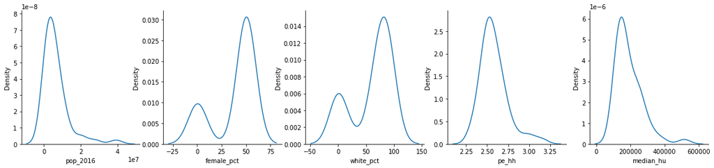

```python
# plotting the kde of some variables to have a sense of the data distribution


fig, (ax1, ax2, ax3, ax4, ax5) = plt.subplots(1, 5, figsize=(20,4))


sns.kdeplot(data=df1, x='pop_2016', ax=ax1)
sns.kdeplot(data=df1, x='female_pct', ax=ax2)
sns.kdeplot(data=df1, x='white_pct', ax=ax3)
sns.kdeplot(data=df1, x='pe_hh', ax=ax4)
sns.kdeplot(data=df1, x='median_hu', ax=ax5)

sns.despine(right=True)
sns.despine(offset=0, trim=False)
```

Upon viewing the kde plot, there seems to be some unusually low values for the percentages columns. This was a reesult of some of the percentage columns being formatted as decimals After inspection, I identified the offending rows as rows[30:42]. To correct these rows, I simply target rows having values less than a benchmark below which the values cannot possibly be valid and multiply by 100

```python
# correcting `female_pct` column
mask1 = df1['female_pct'] < 5
col1 = ['female_pct']
df1.loc[mask1, col1] = df1.loc[mask1, col1] * 100
```

```python
# checking that values are reasonable
df1.female_pct.describe()
```

```
count    50.000000
mean     50.564000
std       0.801213
min      47.700000
25%      50.200000
50%      50.650000
75%      51.175000
max      51.600000
Name: female_pct, dtype: float64
```

```python
# checking offending rows
df1.white_pct[30:42]
```

```
30    0.826
31    0.699
32    0.710
33    0.879
34    0.825
35    0.746
36    0.874
37    0.824
38    0.844
39    0.685
40    0.852
41    0.787
Name: white_pct, dtype: float64
```

```python
# standardizing
mask3 = df1['white_pct'] < 1
col3 = ['white_pct']
df1.loc[mask3, col3] = df1.loc[mask3, col3] * 100
```

```python
# checking result
df1.white_pct[30:42]
```

```
30    82.6
31    69.9
32    71.0
33    87.9
34    82.5
35    74.6
36    87.4
37    82.4
38    84.4
39    68.5
40    85.2
41    78.7
Name: white_pct, dtype: float64
```

```python
# fishing rows
df1.black_pct.sort_values()
```

```
40     0.020
36     0.021
30     0.025
33     0.029
35     0.078
38     0.081
37     0.118
34     0.128
41     0.171
31     0.177
32     0.222
39     0.275
25     0.600
11     0.800
49     1.300
```

[output cut: 36 more lines]

```python
# checking for a particular row to see if indeed the value is valid, which it is
df1.loc[25]
```

```
state                        Montana
pop_2016                   1042520.0
female_pct                      49.7
white_pct                       89.2
black_pct                        0.6
asian_pct                        0.8
pe_hh                           2.41
pe_whi                           9.8
adults_below_65                 60.5
high_school_grad_higher         92.8
bsc_higher                      29.5
median_hu                   193500.0
median_gross_rent              711.0
poverty_pct                     13.3
median_hh_income             47169.0
per_cap_inc                  26381.0
firms                       112419.0
Name: 25, dtype: object
```

```python
# correcting 'black_pct
mask2 = df1['black_pct'] < 0.3
col2 = ['black_pct']
df1.loc[mask2, col2] = df1.loc[mask2, col2] * 100
```

```python
# checking result
df1.black_pct.describe()
```

```
count    50.000000
mean     11.024000
std       9.631868
min       0.600000
25%       3.625000
50%       8.200000
75%      15.525000
max      37.700000
Name: black_pct, dtype: float64
```

```python
# fishing out offending rows
df1.asian_pct.sort_values()
```

```
40     0.015
33     0.015
39     0.016
30     0.017
41     0.018
35     0.022
34     0.022
32     0.029
37     0.035
38     0.036
36     0.045
31     0.089
47     0.800
25     0.800
49     1.000
```

[output cut: 36 more lines]

```python
mask4 = df1['asian_pct'] < 0.3
col4 = ['asian_pct']
df1.loc[mask4, col4] = df1.loc[mask4, col4] * 100
```

```python
# checking results
df1.asian_pct.describe()
```

```
count    50.000000
mean      4.342000
std       5.561973
min       0.800000
25%       1.725000
50%       2.850000
75%       4.775000
max      37.700000
Name: asian_pct, dtype: float64
```

```python
# correcting 'high_school_grad_higher'
mask5 = df1['high_school_grad_higher'] < 5
col5 = ['high_school_grad_higher']
df1.loc[mask5, col5] = df1.loc[mask5, col5] * 100
```

```python
# checking result
df1.bsc_higher.describe()
```

```
count    50.000000
mean     22.363160
std      13.383697
min       0.241000
25%      19.575000
50%      27.200000
75%      31.075000
max      40.500000
Name: bsc_higher, dtype: float64
```

```python
#
df1.bsc_higher.sort_values()
```

```
35     0.241
41     0.249
39     0.258
34     0.261
30     0.263
40     0.270
33     0.277
32     0.284
37     0.286
36     0.308
38     0.319
31     0.342
47    19.200
23    20.700
3     21.100
```

[output cut: 36 more lines]

```python
#
mask6 = df1['bsc_higher'] < 2
col6 = ['bsc_higher']
df1.loc[mask6, col6] = df1.loc[mask6, col6] * 100
```

```python
#
df1.bsc_higher.describe()
```

```
count    50.00000
mean     29.01200
std       4.93404
min      19.20000
25%      25.95000
50%      28.20000
75%      31.77500
max      40.50000
Name: bsc_higher, dtype: float64
```

```python
#
mask7 = df1['pe_whi'] < 1
col7 = ['pe_whi']
df1.loc[mask7, col7] = df1.loc[mask7, col7] * 100
```

```python
# correcting the last % column
mask8 = df1['poverty_pct'] < 1
col8 = ['poverty_pct']
df1.loc[mask8, col8] = df1.loc[mask8, col8] * 100
```

```python
# checking the summary statistics again
df1.describe()
```

|  | pop_2016 | female_pct | white_pct | black_pct | asian_pct | pe_hh | pe_whi | adults_below_65 | high_school_grad_higher | bsc_higher | median_hu | median_gross_rent | poverty_pct | median_hh_income | per_cap_inc | firms |
| --- | --- | --- | --- | --- | --- | --- | --- | --- | --- | --- | --- | --- | --- | --- | --- | --- |
| count | 5.000000e+01 | 50.000000 | 50.000000 | 50.000000 | 50.000000 | 50.000000 | 50.000000 | 50.00000 | 50.000000 | 50.00000 | 50.000000 | 50.000000 | 50.000000 | 50.000000 | 50.000000 | 5.000000e+01 |
| mean | 6.448927e+06 | 50.564000 | 79.308000 | 11.024000 | 4.342000 | 2.582000 | 9.310000 | 70.76378 | 88.224000 | 29.01200 | 192026.000000 | 879.880000 | 13.518000 | 54311.860000 | 28491.780000 | 5.548918e+05 |
| std | 7.271769e+06 | 0.801213 | 12.335908 | 9.631868 | 5.561973 | 0.164105 | 3.456095 | 16.41933 | 3.089585 | 4.93404 | 79742.431821 | 181.106761 | 3.019778 | 8949.529115 | 4103.284534 | 6.645229e+05 |
| min | 5.855010e+05 | 47.700000 | 25.800000 | 0.600000 | 0.800000 | 2.320000 | 2.900000 | 58.90000 | 81.800000 | 19.20000 | 103100.000000 | 643.000000 | 7.300000 | 39665.000000 | 21057.000000 | 6.242700e+04 |
| 25% | 1.850106e+06 | 50.200000 | 72.475000 | 3.625000 | 1.725000 | 2.482500 | 6.625000 | 61.15000 | 85.600000 | 25.95000 | 136600.000000 | 743.500000 | 11.300000 | 47526.000000 | 25443.750000 | 1.478222e+05 |
| 50% | 4.559320e+06 | 50.650000 | 82.100000 | 8.200000 | 2.850000 | 2.550000 | 9.350000 | 62.25000 | 88.850000 | 28.20000 | 165900.000000 | 818.500000 | 13.300000 | 52601.000000 | 27669.500000 | 3.535155e+05 |
| 75% | 7.198768e+06 | 51.175000 | 87.500000 | 15.525000 | 4.775000 | 2.637500 | 11.550000 | 64.30000 | 90.850000 | 31.77500 | 237300.000000 | 1001.500000 | 15.375000 | 60599.000000 | 30977.000000 | 5.933612e+05 |
| max | 3.925002e+07 | 51.600000 | 94.800000 | 37.700000 | 37.700000 | 3.150000 | 18.600000 | 99.63800 | 92.800000 | 40.50000 | 515300.000000 | 1438.000000 | 20.800000 | 74551.000000 | 38803.000000 | 3.548449e+06 |

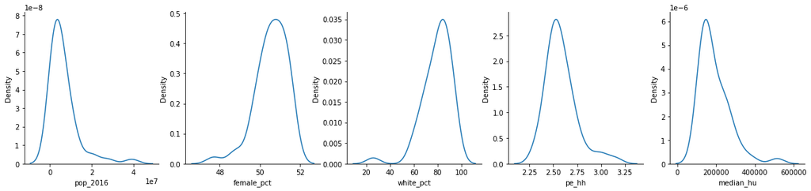

```python
# checking distribution again
# plotting the kde of some variables to have a sense of the data distribution


fig, (ax1, ax2, ax3, ax4, ax5) = plt.subplots(1, 5, figsize=(20,4))


sns.kdeplot(data=df1, x='pop_2016', ax=ax1)
sns.kdeplot(data=df1, x='female_pct', ax=ax2)
sns.kdeplot(data=df1, x='white_pct', ax=ax3)
sns.kdeplot(data=df1, x='pe_hh', ax=ax4)
sns.kdeplot(data=df1, x='median_hu', ax=ax5)

sns.despine(right=True)
sns.despine(offset=0, trim=False)
```

Now, the min values have no unusual numbers  
Proceeding to EDA...

## Preliminary Exploration on the Census Data

*Since the census dataset isn't the focus of this analysis, I will just do some brief exploration of the dataframe*

- *What are the most populated and least states?*
- *Which states have highest and least black population?*
- *Which states have highest and lowest median household income?*

```python
# What are the most populated and least states?
a = df1[['state', 'pop_2016']].nlargest(5,'pop_2016')
b = df1[['state', 'pop_2016']].nsmallest(5,'pop_2016')

c_list = [a, b]
pd.concat(c_list, keys=['most populated', 'least pupulated'], axis='rows')
```

|  |  | state | pop_2016 |
| --- | --- | --- | --- |
| most populated | 4 | California | 39250017.0 |
|  | 42 | Texas | 27862596.0 |
|  | 8 | Florida | 20612439.0 |
|  | 31 | New York | 19745289.0 |
|  | 12 | Illinois | 12801539.0 |
| least pupulated | 49 | Wyoming | 585501.0 |
|  | 44 | Vermont | 624594.0 |
|  | 1 | Alaska | 741894.0 |
|  | 33 | North Dakota | 757952.0 |
|  | 40 | South Dakota | 865454.0 |

```python
# Which states have highest and least black population?
a = df1[['state', 'black_pct']].nlargest(5,'black_pct')
b = df1[['state', 'black_pct']].nsmallest(5,'black_pct')

c_list = [a, b]
pd.concat(c_list, keys=['high black population', 'low black population'], axis='rows')
```

|  |  | state | black_pct |
| --- | --- | --- | --- |
| high black population | 23 | Mississippi | 37.7 |
|  | 17 | Louisiana | 32.6 |
|  | 9 | Georgia | 32.0 |
|  | 19 | Maryland | 30.7 |
|  | 39 | South Carolina | 27.5 |
| low black population | 25 | Montana | 0.6 |
|  | 11 | Idaho | 0.8 |
|  | 44 | Vermont | 1.3 |
|  | 49 | Wyoming | 1.3 |
|  | 43 | Utah | 1.4 |

```python
# Which states have highest and lowest median household income?
a = df1[['state', 'median_hh_income']].nlargest(5,'median_hh_income')
b = df1[['state', 'median_hh_income']].nsmallest(5,'median_hh_income')
c_list = [a, b]
pd.concat(c_list, keys=['high median household income ($)', 'low median household income ($)'], axis='rows')
```

|  |  | state | median_hh_income |
| --- | --- | --- | --- |
| high median household income ($) | 19 | Maryland | 74551.0 |
|  | 1 | Alaska | 72515.0 |
|  | 29 | New Jersey | 72093.0 |
|  | 6 | Connecticut | 70331.0 |
|  | 10 | Hawaii | 69515.0 |
| low median household income ($) | 23 | Mississippi | 39665.0 |
|  | 3 | Arkansas | 41371.0 |
|  | 47 | West Virginia | 41751.0 |
|  | 0 | Alabama | 43623.0 |
|  | 16 | Kentucky | 43740.0 |

```python
# saving for later
df1.to_csv('df_census_cleaned_v2.csv', index=0)
```

# Preparing Gun Sales Data for EDA

*In this section, I will prepare the dataframe for EDA*:

```python
# Reading in the dataset, and viewing heads, tails and  and random sample of the rows
df2 = pd.read_csv('df_gun_cleaned.csv', index_col=0)
df2.head()
```

|  | state | handgun | long_gun | multiple | year | month |
| --- | --- | --- | --- | --- | --- | --- |
| 0 | Alabama | 5734.0 | 6320.0 | 317 | 2017 | 9 |
| 1 | Alaska | 2320.0 | 2930.0 | 160 | 2017 | 9 |
| 2 | Arizona | 11063.0 | 7946.0 | 631 | 2017 | 9 |
| 3 | Arkansas | 4347.0 | 6063.0 | 366 | 2017 | 9 |
| 4 | California | 37165.0 | 24581.0 | 0 | 2017 | 9 |

```python
# checking tail of data
df2.tail()
```

|  | state | handgun | long_gun | multiple | year | month |
| --- | --- | --- | --- | --- | --- | --- |
| 12480 | Virginia | 14.0 | 2.0 | 8 | 1998 | 11 |
| 12481 | Washington | 65.0 | 286.0 | 8 | 1998 | 11 |
| 12482 | West Virginia | 149.0 | 251.0 | 5 | 1998 | 11 |
| 12483 | Wisconsin | 25.0 | 214.0 | 2 | 1998 | 11 |
| 12484 | Wyoming | 45.0 | 49.0 | 5 | 1998 | 11 |

```python
# viewing random sample
df2.sample(n=5)
```

|  | state | handgun | long_gun | multiple | year | month |
| --- | --- | --- | --- | --- | --- | --- |
| 2568 | Oklahoma | 12481.0 | 17046.0 | 929 | 2013 | 11 |
| 7855 | Tennessee | 7462.0 | 15154.0 | 346 | 2005 | 11 |
| 7616 | Mississippi | 4796.0 | 6139.0 | 181 | 2006 | 3 |
| 10899 | Florida | 11532.0 | 10239.0 | 420 | 2001 | 3 |
| 5959 | Louisiana | 5467.0 | 9719.0 | 245 | 2008 | 9 |

```python
# Getting the dimensions of the DataFrame with the .shape attribute:
df2.shape
```

```
(12485, 6)
```

```python
# checking for nulls
df2.isnull().sum()
```

```
state        0
handgun     20
long_gun    19
multiple     0
year         0
month        0
dtype: int64
```

```python
# revealing the nulls
mask = df2.long_gun.isnull()
df2[mask]
```

|  | state | handgun | long_gun | multiple | year | month |
| --- | --- | --- | --- | --- | --- | --- |
| 7914 | Virgin Islands | NaN | NaN | 0 | 2005 | 10 |
| 7969 | Virgin Islands | NaN | NaN | 0 | 2005 | 9 |
| 8024 | Virgin Islands | NaN | NaN | 0 | 2005 | 8 |
| 8079 | Virgin Islands | NaN | NaN | 0 | 2005 | 7 |
| 8134 | Virgin Islands | NaN | NaN | 0 | 2005 | 6 |
| 8189 | Virgin Islands | NaN | NaN | 0 | 2005 | 5 |
| 8299 | Virgin Islands | NaN | NaN | 0 | 2005 | 3 |
| 8354 | Virgin Islands | NaN | NaN | 0 | 2005 | 2 |
| 8409 | Virgin Islands | NaN | NaN | 0 | 2005 | 1 |
| 8491 | Mariana Islands | NaN | NaN | 0 | 2004 | 11 |
| 9674 | Virgin Islands | NaN | NaN | 0 | 2003 | 2 |
| 12011 | Mariana Islands | NaN | NaN | 0 | 1999 | 7 |
| 12066 | Mariana Islands | NaN | NaN | 0 | 1999 | 6 |
| 12121 | Mariana Islands | NaN | NaN | 0 | 1999 | 5 |
| 12176 | Mariana Islands | NaN | NaN | 0 | 1999 | 4 |
| 12231 | Mariana Islands | NaN | NaN | 0 | 1999 | 3 |
| 12286 | Mariana Islands | NaN | NaN | 0 | 1999 | 2 |
| 12341 | Mariana Islands | NaN | NaN | 0 | 1999 | 1 |
| 12396 | Mariana Islands | NaN | NaN | 0 | 1998 | 12 |

After doing some research, I could not find adequate data on gun purchases on these islands. If any, I figured it is going to be insubstantial anyway. So I proceed to fill these NaNs with zero.

```python
# fill nans with 0
df2.long_gun.fillna(0, inplace=True)
df2.handgun.fillna(0, inplace=True)
```

```python
# inspecting
df2.isnull().sum()
```

```
state       0
handgun     0
long_gun    0
multiple    0
year        0
month       0
dtype: int64
```

```python
#  List the data type of each column, the number of non-missing values, and memory usage with the .info method:
df2.info()
```

```
<class 'pandas.core.frame.DataFrame'>
Int64Index: 12485 entries, 0 to 12484
Data columns (total 6 columns):
 #   Column    Non-Null Count  Dtype
---  ------    --------------  -----
 0   state     12485 non-null  object
 1   handgun   12485 non-null  float64
 2   long_gun  12485 non-null  float64
 3   multiple  12485 non-null  int64
 4   year      12485 non-null  int64
 5   month     12485 non-null  int64
dtypes: float64(2), int64(3), object(1)
memory usage: 682.8+ KB
```

```python
# saving for later
df2.to_csv('df2_gun_cleaned_v2.csv', index=False)
```

```python
df2 = pd.read_csv('df2_gun_cleaned_v2.csv')
df2.head()
```

|  | state | handgun | long_gun | multiple | year | month |
| --- | --- | --- | --- | --- | --- | --- |
| 0 | Alabama | 5734.0 | 6320.0 | 317 | 2017 | 9 |
| 1 | Alaska | 2320.0 | 2930.0 | 160 | 2017 | 9 |
| 2 | Arizona | 11063.0 | 7946.0 | 631 | 2017 | 9 |
| 3 | Arkansas | 4347.0 | 6063.0 | 366 | 2017 | 9 |
| 4 | California | 37165.0 | 24581.0 | 0 | 2017 | 9 |

There are 12485 rows in this dataset representing each month per state, from 1998 - 2017 The data is clean: there are no null values, and the datatypes are appropriately assigned

## Data Dictionary

[output not shown]

```python
# displaying summary statistics
df2.describe()
```

|  | handgun | long_gun | multiple | year | month |
| --- | --- | --- | --- | --- | --- |
| count | 12485.000000 | 12485.000000 | 12485.000000 | 12485.000000 | 12485.000000 |
| mean | 5931.364277 | 7798.960833 | 268.603364 | 2007.792952 | 6.484581 |
| std | 8614.954626 | 9307.740581 | 783.185073 | 5.468296 | 3.451944 |
| min | 0.000000 | 0.000000 | 0.000000 | 1998.000000 | 1.000000 |
| 25% | 857.000000 | 2063.000000 | 15.000000 | 2003.000000 | 3.000000 |
| 50% | 3046.000000 | 5114.000000 | 125.000000 | 2008.000000 | 6.000000 |
| 75% | 7277.000000 | 10374.000000 | 301.000000 | 2013.000000 | 9.000000 |
| max | 107224.000000 | 108058.000000 | 38907.000000 | 2017.000000 | 12.000000 |

```python
# Following a [NY Times recommendation], gun sales can be approximated from check calls
# by multiplying checks for handgun and long_gun by a factor of 1.1 and that of multiple by 2

df2['handgun'] = df2['handgun'].mul(1.1)
df2['long_gun'] = df2['long_gun'].mul(1.1)
df2['multiple'] = df2['multiple'].mul(2)


df2.head()
```

|  | state | handgun | long_gun | multiple | year | month |
| --- | --- | --- | --- | --- | --- | --- |
| 0 | Alabama | 6307.4 | 6952.0 | 634 | 2017 | 9 |
| 1 | Alaska | 2552.0 | 3223.0 | 320 | 2017 | 9 |
| 2 | Arizona | 12169.3 | 8740.6 | 1262 | 2017 | 9 |
| 3 | Arkansas | 4781.7 | 6669.3 | 732 | 2017 | 9 |
| 4 | California | 40881.5 | 27039.1 | 0 | 2017 | 9 |

```python
# I am interested in gun trends in 2006, 2015 and 2016
# so I extract data for those years

df2_2006 = df2[df2['year'] == 2006]
df2_2015 = df2[df2['year'] == 2015]
df2_2016 = df2[df2['year'] == 2016]
```

```python
# Since the year variable is now redundant, I opt to drop them
# I use the reset_index method to have the index start from 0

df2_2006 = df2_2006.drop(columns='year').reset_index(drop=True)
df2_2015 = df2_2015.drop(columns='year').reset_index(drop=True)
df2_2016 = df2_2016.drop(columns='year').reset_index(drop=True)
```

```python
# checking the result
df2_2006.head(3)
```

|  | state | handgun | long_gun | multiple | month |
| --- | --- | --- | --- | --- | --- |
| 0 | Alabama | 11031.9 | 28608.8 | 882 | 12 |
| 1 | Alaska | 2190.1 | 3166.9 | 162 | 12 |
| 2 | Arizona | 9188.3 | 12136.3 | 690 | 12 |

```python
# saving for later
df2_2006.to_csv('df2_2006.csv')
df2_2015.to_csv('df2_2015.csv')
df2_2016.to_csv('df2_2016.csv')
```

Viewing the head of the three dataframes

```python
df2_2006 = pd.read_csv('df2_2006.csv', index_col=0)
df2_2015 = pd.read_csv('df2_2015.csv', index_col=0)
df2_2016 = pd.read_csv('df2_2016.csv', index_col=0)

df2_2006.head()
```

|  | state | handgun | long_gun | multiple | month |
| --- | --- | --- | --- | --- | --- |
| 0 | Alabama | 11031.9 | 28608.8 | 882 | 12 |
| 1 | Alaska | 2190.1 | 3166.9 | 162 | 12 |
| 2 | Arizona | 9188.3 | 12136.3 | 690 | 12 |
| 3 | Arkansas | 4814.7 | 17008.2 | 460 | 12 |
| 4 | California | 17902.5 | 22993.3 | 15684 | 12 |

```python
df2_2015.head()
```

|  | state | handgun | long_gun | multiple | month |
| --- | --- | --- | --- | --- | --- |
| 0 | Alabama | 52365.5 | 37081.0 | 3504 | 12 |
| 1 | Alaska | 5791.5 | 5101.8 | 428 | 12 |
| 2 | Arizona | 28118.2 | 16197.5 | 1990 | 12 |
| 3 | Arkansas | 15158.0 | 16765.1 | 1042 | 12 |
| 4 | California | 81838.9 | 53638.2 | 0 | 12 |

```python
df2_2016.head()
```

|  | state | handgun | long_gun | multiple | month |
| --- | --- | --- | --- | --- | --- |
| 0 | Alabama | 15106.3 | 19270.9 | 1066 | 12 |
| 1 | Alaska | 4495.7 | 4067.8 | 382 | 12 |
| 2 | Arizona | 19826.4 | 15163.5 | 1406 | 12 |
| 3 | Arkansas | 10111.2 | 14776.3 | 770 | 12 |
| 4 | California | 70013.9 | 102546.4 | 0 | 12 |

# Exploratory Data Analysis 2

### (Gun Sales Data)

*In this section, I will answer the following research questions*:

> Year Level Questions:
> - *How many guns were sold in the U.S. in 2006?*
> - *What kind of gun was bought the most?*
> - *What are the overall monthly trends of gun purchases in 2006?*

> State Level Questions
> - What are the top 5 states in terms of gun purchases in the U.S. in 2006?
> - What are the most bought gun types in those states?
> - What kind of gun was bought the most in one of those states?
> - What are the overall monthly trends of gun purchases in those states?

> Which states had the highest growth in gun sales over the span of a decade?

# 2006

```python
df2_2006 = pd.read_csv('df2_2006.csv', index_col=0)
df2_2006.head()
```

|  | state | handgun | long_gun | multiple | month |
| --- | --- | --- | --- | --- | --- |
| 0 | Alabama | 11031.9 | 28608.8 | 882 | 12 |
| 1 | Alaska | 2190.1 | 3166.9 | 162 | 12 |
| 2 | Arizona | 9188.3 | 12136.3 | 690 | 12 |
| 3 | Arkansas | 4814.7 | 17008.2 | 460 | 12 |
| 4 | California | 17902.5 | 22993.3 | 15684 | 12 |

```python
df2_2006.describe().T
```

|  | count | mean | std | min | 25% | 50% | 75% | max |
| --- | --- | --- | --- | --- | --- | --- | --- | --- |
| handgun | 660.0 | 4068.875000 | 4725.841945 | 0.0 | 671.00 | 2560.25 | 5929.00 | 27432.9 |
| long_gun | 660.0 | 7982.651667 | 9051.901614 | 0.0 | 2091.10 | 5649.60 | 10799.80 | 68093.3 |
| multiple | 660.0 | 394.293939 | 779.232091 | 0.0 | 55.50 | 232.00 | 522.00 | 15684.0 |
| month | 660.0 | 6.500000 | 3.454671 | 1.0 | 3.75 | 6.50 | 9.25 | 12.0 |

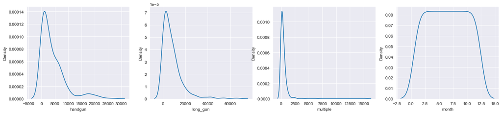

```python
# plotting the kde of the variables to have a sense of the data distribution
# check how to change line color

sns.set_style('darkgrid')
fig, (ax1, ax2, ax3, ax4) = plt.subplots(1, 4, figsize=(20,4))


sns.kdeplot(data=df2_2006, x='handgun', ax=ax1)

sns.kdeplot(data=df2_2006, x='long_gun', ax=ax2)
sns.kdeplot(data=df2_2006, x='multiple', ax=ax3)
sns.kdeplot(data=df2_2006, x='month', ax=ax4)


sns.despine(right=True)
sns.despine(offset=0, trim=False)
```

`Deriving Conclusions`

## Year Level Questions

- How many guns were sold in the U.S. in 2006?
- What kind of gun was bought the most?
- What are the overall monthly trends of gun purchases in 2006?

*How many guns were sold in the U.S. in 2006?*

```python
df2_2006[['handgun', 'long_gun', 'multiple']].sum().sum()
```

```
8214241.6000000015
```

*What type of gun sold the most?*

```
long_gun    5268550.1
handgun     2685457.5
multiple     260234.0
dtype: float64
```

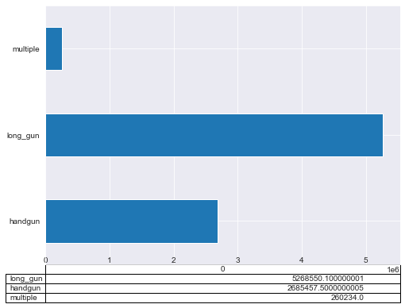

```python
sns.set_style('darkgrid')
fig, ax = plt.subplots(figsize=(8,6))

d = df2_2006[['handgun', 'long_gun', 'multiple']].sum().sort_values(ascending=False)

df2_2006[['handgun', 'long_gun', 'multiple']].sum().plot.barh(table=d)
plt.setp(ax.get_xticklabels(), y=.05)
plt.setp(ax.get_xticklines(), visible=False)

print(df2_2006[['handgun', 'long_gun', 'multiple']].sum().sort_values(ascending=False))
```

*What is the trend of gun sales throughout the year in 2006?*

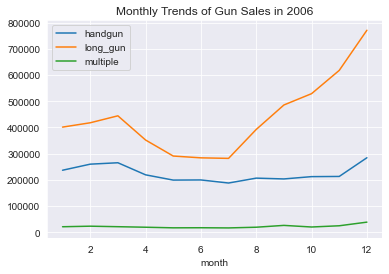

```python
df2_2006.groupby('month')[['handgun', 'long_gun', 'multiple']].sum().plot.line(title='Monthly Trends of Gun Sales in 2006')
```

## State Level Questions

- What are the top 5 states in terms of gun purchases in the U.S. in 2006?
- What are the most bought gun types in those states?
- What are the overall monthly trends of gun purchases in those states?

*What are the top 5 states in terms of gun purchases in the U.S. in 2006?*

```python
df2_2006.head()
```

|  | state | handgun | long_gun | multiple | month |
| --- | --- | --- | --- | --- | --- |
| 0 | Alabama | 11031.9 | 28608.8 | 882 | 12 |
| 1 | Alaska | 2190.1 | 3166.9 | 162 | 12 |
| 2 | Arizona | 9188.3 | 12136.3 | 690 | 12 |
| 3 | Arkansas | 4814.7 | 17008.2 | 460 | 12 |
| 4 | California | 17902.5 | 22993.3 | 15684 | 12 |

```python
df2_2006['total'] = df2_2006['handgun'] + df2_2006['long_gun'] + df2_2006['multiple']
df2_2006.head()
```

|  | state | handgun | long_gun | multiple | month | total |
| --- | --- | --- | --- | --- | --- | --- |
| 0 | Alabama | 11031.9 | 28608.8 | 882 | 12 | 40522.7 |
| 1 | Alaska | 2190.1 | 3166.9 | 162 | 12 | 5519.0 |
| 2 | Arizona | 9188.3 | 12136.3 | 690 | 12 | 22014.6 |
| 3 | Arkansas | 4814.7 | 17008.2 | 460 | 12 | 22282.9 |
| 4 | California | 17902.5 | 22993.3 | 15684 | 12 | 56579.8 |

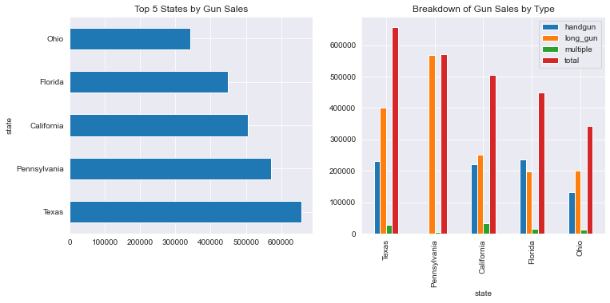

```python
sns.set_style('darkgrid')
fig, (ax1, ax2) = plt.subplots(1, 2, figsize=(12, 5))

df2_2006.groupby('state')['total'].sum().sort_values(ascending=False).head().plot.barh(ax=ax1, title='Top 5 States by Gun Sales')
df2_2006.groupby('state')[['handgun', 'long_gun', 'multiple','total']].sum().nlargest(5, 'total').plot.bar(ax=ax2, title='Breakdown of Gun Sales by Type')
```

*What are the top 5 states in terms of gun purchases in the U.S. in 2006?*  
*What are the most bought gun types in those states?*

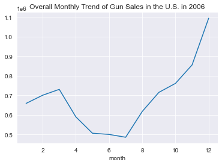

```python
# What are the overall monthly trends of gun purchases overall and in those top 5 states?
# i.e month on x, sales on y, faceted by states

df2_2006.groupby('month')['total'].sum().plot.line(title = 'Overall Monthly Trend of Gun Sales in the U.S. in 2006')
```

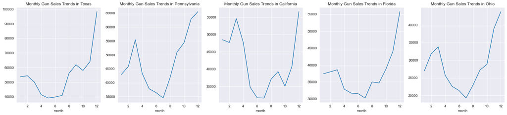

```python
fig, (ax1, ax2, ax3, ax4, ax5) = plt.subplots(1,5, figsize=(25,5))
crit_1 = df2_2006.state == 'Texas'
crit_2 = df2_2006.state == 'Pennsylvania'
crit_3 = df2_2006.state == 'California'
crit_4 = df2_2006.state == 'Florida'
crit_5 = df2_2006.state == 'Ohio'

df2_2006[crit_1].groupby('month')['total'].sum().plot.line(ax=ax1, title='Monthly Gun Sales Trends in Texas')
df2_2006[crit_2].groupby('month')['total'].sum().plot.line(ax=ax2, title='Monthly Gun Sales Trends in Pennsylvania')
df2_2006[crit_3].groupby('month')['total'].sum().plot.line(ax=ax3, title='Monthly Gun Sales Trends in California')
df2_2006[crit_4].groupby('month')['total'].sum().plot.line(ax=ax4, title='Monthly Gun Sales Trends in Florida')
df2_2006[crit_5].groupby('month')['total'].sum().plot.line(ax=ax5, title='Monthly Gun Sales Trends in Ohio')
```

# 2015

```python
# reading in the dataframe
df2_2015 = pd.read_csv('df2_2015.csv', index_col=0)
```

```python
# summary statistics
df2_2015.describe().T
```

|  | count | mean | std | min | 25% | 50% | 75% | max |
| --- | --- | --- | --- | --- | --- | --- | --- | --- |
| handgun | 660.0 | 12223.013333 | 14992.577178 | 0.0 | 2365.275 | 7451.4 | 16526.125 | 117946.4 |
| long_gun | 660.0 | 9132.401667 | 9448.716863 | 0.0 | 2820.675 | 6436.1 | 12730.850 | 88271.7 |
| multiple | 660.0 | 734.469697 | 1043.362297 | 0.0 | 17.500 | 349.0 | 1024.500 | 9010.0 |
| month | 660.0 | 6.500000 | 3.454671 | 1.0 | 3.750 | 6.5 | 9.250 | 12.0 |

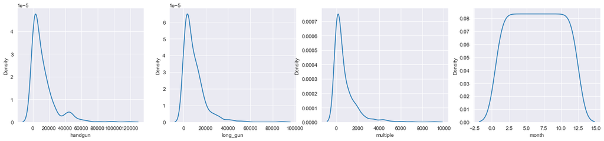

```python
# plotting the kde of the variables to have a sense of the data distribution
# check how to change line color

sns.set_style('darkgrid')
fig, (ax1, ax2, ax3, ax4) = plt.subplots(1, 4, figsize=(20,4))


sns.kdeplot(data=df2_2015, x='handgun', ax=ax1)
sns.kdeplot(data=df2_2015, x='long_gun', ax=ax2)
sns.kdeplot(data=df2_2015, x='multiple', ax=ax3)
sns.kdeplot(data=df2_2015, x='month', ax=ax4)


sns.despine(right=True)
sns.despine(offset=0, trim=False)
```

`Deriving Conclusions`

## Year Level Questions

- How many guns were sold in the U.S. in 2015?
- What kind of gun was bought the most?
- What are the overall monthly trends of gun purchases in 2015?

*How many guns were sold in the U.S. in 2015?*

```python
df2_2015[['handgun', 'long_gun', 'multiple']].sum().sum()
```

```
14579323.900000002
```

*What type of gun sold the most?*

```
handgun     8067188.8
long_gun    6027385.1
multiple     484750.0
dtype: float64
```

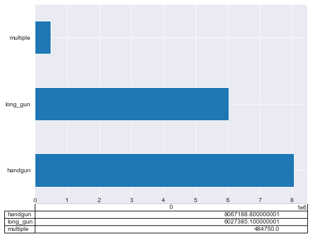

```python
sns.set_style('darkgrid')
fig, ax = plt.subplots(figsize=(8,6))

d = df2_2015[['handgun', 'long_gun', 'multiple']].sum().sort_values(ascending=False)

df2_2015[['handgun', 'long_gun', 'multiple']].sum().plot.barh(table=d)
plt.setp(ax.get_xticklabels(), y=.05)
plt.setp(ax.get_xticklines(), visible=False)

print(df2_2015[['handgun', 'long_gun', 'multiple']].sum().sort_values(ascending=False))
```

*Trend of gun sales throughout the year in 2015*

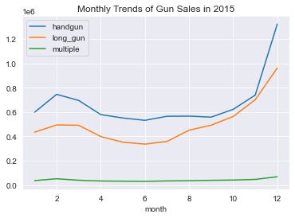

```python
df2_2015.groupby('month')[['handgun', 'long_gun', 'multiple']].sum().plot.line(title='Monthly Trends of Gun Sales in 2015')
```

## State Level Questions

- What are the top 5 states in terms of gun purchases in the U.S. in 2015?
- What are the most bought gun types in those states?
- What kind of gun was bought the most in one of those states?
- What are the overall monthly trends of gun purchases in those states?

```python
# reading in the data
df2_2015.head()
```

|  | state | handgun | long_gun | multiple | month |
| --- | --- | --- | --- | --- | --- |
| 0 | Alabama | 52365.5 | 37081.0 | 3504 | 12 |
| 1 | Alaska | 5791.5 | 5101.8 | 428 | 12 |
| 2 | Arizona | 28118.2 | 16197.5 | 1990 | 12 |
| 3 | Arkansas | 15158.0 | 16765.1 | 1042 | 12 |
| 4 | California | 81838.9 | 53638.2 | 0 | 12 |

```python
# deriving 'total' columns
df2_2015['total'] = df2_2015['handgun'] + df2_2015['long_gun'] + df2_2015['multiple']
df2_2015.head()
```

|  | state | handgun | long_gun | multiple | month | total |
| --- | --- | --- | --- | --- | --- | --- |
| 0 | Alabama | 52365.5 | 37081.0 | 3504 | 12 | 92950.5 |
| 1 | Alaska | 5791.5 | 5101.8 | 428 | 12 | 11321.3 |
| 2 | Arizona | 28118.2 | 16197.5 | 1990 | 12 | 46305.7 |
| 3 | Arkansas | 15158.0 | 16765.1 | 1042 | 12 | 32965.1 |
| 4 | California | 81838.9 | 53638.2 | 0 | 12 | 135477.1 |

*What are the top 5 states in terms of gun purchases in the U.S. in 2015?* *What are the most bought gun types in those states?*

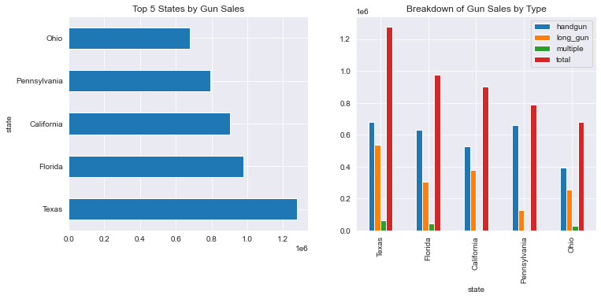

```python
sns.set_style('darkgrid')
fig, (ax1, ax2) = plt.subplots(1, 2, figsize=(12, 5))

df2_2015.groupby('state')['total'].sum().sort_values(ascending=False).head().plot.barh(ax=ax1, title='Top 5 States by Gun Sales')
df2_2015.groupby('state')[['handgun', 'long_gun', 'multiple','total']].sum().nlargest(5, 'total').plot.bar(ax=ax2, title='Breakdown of Gun Sales by Type')
```

*What are the overall monthly trends of gun purchases overall and in those top 5 states?*

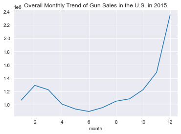

```python
df2_2015.groupby('month')['total'].sum().plot.line(title = 'Overall Monthly Trend of Gun Sales in the U.S. in 2015')
```

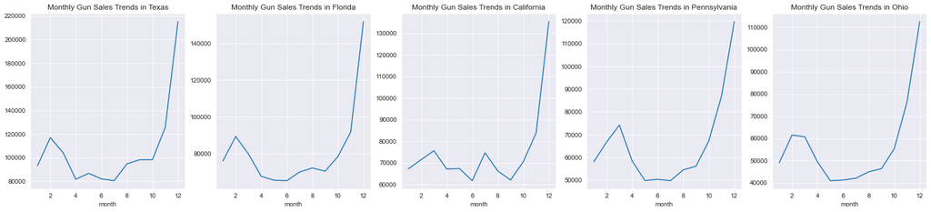

```python
fig, (ax1, ax2, ax3, ax4, ax5) = plt.subplots(1,5, figsize=(25,5))
crit_1 = df2_2015.state == 'Texas'
crit_2 = df2_2015.state == 'Florida'
crit_3 = df2_2015.state == 'California'
crit_4 = df2_2015.state == 'Pennsylvania'
crit_5 = df2_2015.state == 'Ohio'

df2_2015[crit_1].groupby('month')['total'].sum().plot.line(ax=ax1, title='Monthly Gun Sales Trends in Texas')
df2_2015[crit_2].groupby('month')['total'].sum().plot.line(ax=ax2, title='Monthly Gun Sales Trends in Florida')
df2_2015[crit_3].groupby('month')['total'].sum().plot.line(ax=ax3, title='Monthly Gun Sales Trends in California')
df2_2015[crit_4].groupby('month')['total'].sum().plot.line(ax=ax4, title='Monthly Gun Sales Trends in Pennsylvania')
df2_2015[crit_5].groupby('month')['total'].sum().plot.line(ax=ax5, title='Monthly Gun Sales Trends in Ohio')
```

# 2016

```python
# reading in the data
df2_2016 = pd.read_csv('df2_2016.csv', index_col=0)
df2_2016.head()
```

|  | state | handgun | long_gun | multiple | month |
| --- | --- | --- | --- | --- | --- |
| 0 | Alabama | 15106.3 | 19270.9 | 1066 | 12 |
| 1 | Alaska | 4495.7 | 4067.8 | 382 | 12 |
| 2 | Arizona | 19826.4 | 15163.5 | 1406 | 12 |
| 3 | Arkansas | 10111.2 | 14776.3 | 770 | 12 |
| 4 | California | 70013.9 | 102546.4 | 0 | 12 |

```python
# deriving summary statistics
df2_2016.describe().T
```

|  | count | mean | std | min | 25% | 50% | 75% | max |
| --- | --- | --- | --- | --- | --- | --- | --- | --- |
| handgun | 660.0 | 13475.830000 | 15766.508622 | 0.0 | 2685.925 | 7737.95 | 18134.325 | 79888.6 |
| long_gun | 660.0 | 9980.851667 | 10916.172474 | 0.0 | 3268.650 | 6524.10 | 14035.450 | 102546.4 |
| multiple | 660.0 | 780.978788 | 1099.305994 | 0.0 | 16.000 | 401.00 | 1058.000 | 7782.0 |
| month | 660.0 | 6.500000 | 3.454671 | 1.0 | 3.750 | 6.50 | 9.250 | 12.0 |

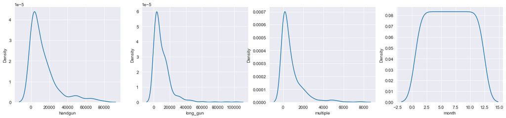

```python
# plotting the kde of the variables to have a sense of the data distribution
# check how to change line color

sns.set_style('darkgrid')
fig, (ax1, ax2, ax3, ax4) = plt.subplots(1, 4, figsize=(20,4))


sns.kdeplot(data=df2_2016, x='handgun', ax=ax1)

sns.kdeplot(data=df2_2016, x='long_gun', ax=ax2)
sns.kdeplot(data=df2_2016, x='multiple', ax=ax3)
sns.kdeplot(data=df2_2016, x='month', ax=ax4)


sns.despine(right=True)
sns.despine(offset=0, trim=False)
```

`Deriving Conclusions`

## Year Level Questions

- How many guns were sold in the U.S. in 2016?
- What kind of gun was bought the most?
- What are the overall monthly trends of gun purchases in 2016?

*How many guns were sold in the U.S. in 2016?*

```python
df2_2016[['handgun', 'long_gun', 'multiple']].sum().sum()
```

```
15996855.9
```

*what type of gun sold the most?*

```
handgun     8894047.8
long_gun    6587362.1
multiple     515446.0
dtype: float64
```

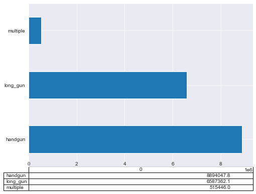

```python
sns.set_style('darkgrid')
fig, ax = plt.subplots(figsize=(8,6))

d = df2_2016[['handgun', 'long_gun', 'multiple']].sum().sort_values(ascending=False)

df2_2016[['handgun', 'long_gun', 'multiple']].sum().plot.barh(table=d)
plt.setp(ax.get_xticklabels(), y=.05)
plt.setp(ax.get_xticklines(), visible=False)

print(df2_2016[['handgun', 'long_gun', 'multiple']].sum().sort_values(ascending=False))
```

*Trend of gun sales throughout the year in 2016*

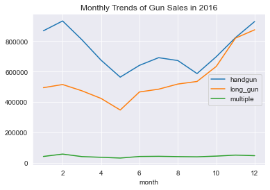

```python
df2_2016.groupby('month')[['handgun', 'long_gun', 'multiple']].sum().plot.line(title='Monthly Trends of Gun Sales in 2016')
```

## State Level Questions

- What are the top 5 states in terms of gun purchases in the U.S. in 2016?
- What are the most bought gun types in those states?
- What kind of gun was bought the most in one of those states?
- What are the overall monthly trends of gun purchases in those states?

```python
df2_2016.head()
```

|  | state | handgun | long_gun | multiple | month |
| --- | --- | --- | --- | --- | --- |
| 0 | Alabama | 15106.3 | 19270.9 | 1066 | 12 |
| 1 | Alaska | 4495.7 | 4067.8 | 382 | 12 |
| 2 | Arizona | 19826.4 | 15163.5 | 1406 | 12 |
| 3 | Arkansas | 10111.2 | 14776.3 | 770 | 12 |
| 4 | California | 70013.9 | 102546.4 | 0 | 12 |

```python
df2_2016['total'] = df2_2016['handgun'] + df2_2016['long_gun'] + df2_2016['multiple']
df2_2016.head()
```

|  | state | handgun | long_gun | multiple | month | total |
| --- | --- | --- | --- | --- | --- | --- |
| 0 | Alabama | 15106.3 | 19270.9 | 1066 | 12 | 35443.2 |
| 1 | Alaska | 4495.7 | 4067.8 | 382 | 12 | 8945.5 |
| 2 | Arizona | 19826.4 | 15163.5 | 1406 | 12 | 36395.9 |
| 3 | Arkansas | 10111.2 | 14776.3 | 770 | 12 | 25657.5 |
| 4 | California | 70013.9 | 102546.4 | 0 | 12 | 172560.3 |

*What are the top 5 states in terms of gun purchases in the U.S. in 2016?*  
*What are the most bought gun types in those states?*

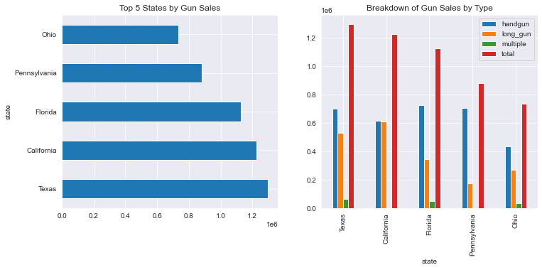

```python
sns.set_style('darkgrid')
fig, (ax1, ax2) = plt.subplots(1, 2, figsize=(12, 5))

df2_2016.groupby('state')['total'].sum().sort_values(ascending=False).head().plot.barh(ax=ax1, title='Top 5 States by Gun Sales')
df2_2016.groupby('state')[['handgun', 'long_gun', 'multiple','total']].sum().nlargest(5, 'total').plot.bar(ax=ax2, title='Breakdown of Gun Sales by Type')
```

*What are the overall monthly trends of gun purchases?*

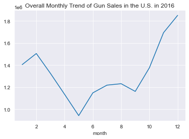

```python
df2_2016.groupby('month')['total'].sum().plot.line(title = 'Overall Monthly Trend of Gun Sales in the U.S. in 2016')
```

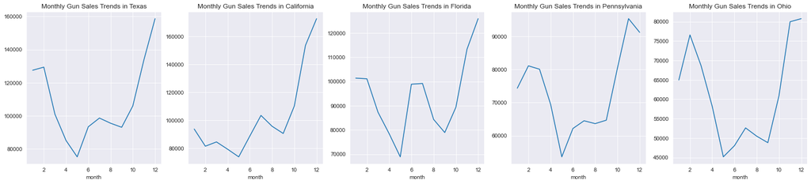

```python
fig, (ax1, ax2, ax3, ax4, ax5) = plt.subplots(1,5, figsize=(25,5))
crit_1 = df2_2016.state == 'Texas'
crit_2 = df2_2016.state == 'California'
crit_3 = df2_2016.state == 'Florida'
crit_4 = df2_2016.state == 'Pennsylvania'
crit_5 = df2_2016.state == 'Ohio'

df2_2016[crit_1].groupby('month')['total'].sum().plot.line(ax=ax1, title='Monthly Gun Sales Trends in Texas')
df2_2016[crit_2].groupby('month')['total'].sum().plot.line(ax=ax2, title='Monthly Gun Sales Trends in California')
df2_2016[crit_3].groupby('month')['total'].sum().plot.line(ax=ax3, title='Monthly Gun Sales Trends in Florida')
df2_2016[crit_4].groupby('month')['total'].sum().plot.line(ax=ax4, title='Monthly Gun Sales Trends in Pennsylvania')
df2_2016[crit_5].groupby('month')['total'].sum().plot.line(ax=ax5, title='Monthly Gun Sales Trends in Ohio')
```

*Which states have the highest growth in gun registrations over the span of a decade?*

```python
# 2016 dataframe is loaded
df2_2016.head()
```

|  | state | handgun | long_gun | multiple | month | total |
| --- | --- | --- | --- | --- | --- | --- |
| 0 | Alabama | 15106.3 | 19270.9 | 1066 | 12 | 35443.2 |
| 1 | Alaska | 4495.7 | 4067.8 | 382 | 12 | 8945.5 |
| 2 | Arizona | 19826.4 | 15163.5 | 1406 | 12 | 36395.9 |
| 3 | Arkansas | 10111.2 | 14776.3 | 770 | 12 | 25657.5 |
| 4 | California | 70013.9 | 102546.4 | 0 | 12 | 172560.3 |

```python
df2_2016['total'] = df2_2016['handgun'] + df2_2016['long_gun'] + df2_2016['multiple']
```

```python
# aggregating df2 on the gun sales columns
df2_2016 = df2_2016.groupby('state')[['handgun','long_gun','multiple', 'total']].sum()
```

```python
# dropping columns
cols = ['handgun', 'long_gun', 'multiple']
df2_2016.drop(columns=cols, inplace=True)
df2_2016.head()
```

| state | total |
| --- | --- |
| Alabama | 315684.6 |
| Alaska | 86447.8 |
| Arizona | 319165.2 |
| Arkansas | 187400.4 |
| California | 1226395.5 |

```python
# renaming for clarity
df2_2016.rename(columns=lambda x: x + "_2016", inplace=True)
df2_2016.head()
```

| state | total_2016 |
| --- | --- |
| Alabama | 315684.6 |
| Alaska | 86447.8 |
| Arizona | 319165.2 |
| Arkansas | 187400.4 |
| California | 1226395.5 |

Now I follow the sme procedures for the 2006 dataframe

```python
df2_2006.head()
```

|  | state | handgun | long_gun | multiple | month | total |
| --- | --- | --- | --- | --- | --- | --- |
| 0 | Alabama | 11031.9 | 28608.8 | 882 | 12 | 40522.7 |
| 1 | Alaska | 2190.1 | 3166.9 | 162 | 12 | 5519.0 |
| 2 | Arizona | 9188.3 | 12136.3 | 690 | 12 | 22014.6 |
| 3 | Arkansas | 4814.7 | 17008.2 | 460 | 12 | 22282.9 |
| 4 | California | 17902.5 | 22993.3 | 15684 | 12 | 56579.8 |

```python
df2_2006['total'] = df2_2006['handgun'] + df2_2006['long_gun'] + df2_2006['multiple']
```

```python
df2_2006 = df2_2006.groupby('state')[['handgun','long_gun','multiple', 'total']].sum()
```

```python
cols = ['handgun', 'long_gun', 'multiple']
df2_2006.drop(columns=cols, inplace=True)
df2_2006.head()
```

| state | total |
| --- | --- |
| Alabama | 232324.7 |
| Alaska | 48404.4 |
| Arizona | 177284.5 |
| Arkansas | 142397.6 |
| California | 504970.9 |

```python
# rename columns for clarity
df2_2006.rename(columns=lambda x: x + "_2006", inplace=True)
df2_2006.head()
```

| state | total_2006 |
| --- | --- |
| Alabama | 232324.7 |
| Alaska | 48404.4 |
| Arizona | 177284.5 |
| Arkansas | 142397.6 |
| California | 504970.9 |

Now, I merge both on 'state'

```python
# merging the dataframe
combined_df = df2_2016.merge(df2_2006, on='state', how='inner')
combined_df.head()
```

| state | total_2016 | total_2006 |
| --- | --- | --- |
| Alabama | 315684.6 | 232324.7 |
| Alaska | 86447.8 | 48404.4 |
| Arizona | 319165.2 | 177284.5 |
| Arkansas | 187400.4 | 142397.6 |
| California | 1226395.5 | 504970.9 |

```python
# add column for total_change
combined_df['total_change'] = combined_df['total_2016'] - combined_df['total_2006']
combined_df.head()
```

| state | total_2016 | total_2006 | total_change |
| --- | --- | --- | --- |
| Alabama | 315684.6 | 232324.7 | 83359.9 |
| Alaska | 86447.8 | 48404.4 | 38043.4 |
| Arizona | 319165.2 | 177284.5 | 141880.7 |
| Arkansas | 187400.4 | 142397.6 | 45002.8 |
| California | 1226395.5 | 504970.9 | 721424.6 |

```python
# adding a column for % change and rounding to 2 d.f.
combined_df['%_change'] = ((combined_df['total_change'] / combined_df['total_2006']) * 100).round(2)
combined_df.head()
```

| state | total_2016 | total_2006 | total_change | %_change |
| --- | --- | --- | --- | --- |
| Alabama | 315684.6 | 232324.7 | 83359.9 | 35.88 |
| Alaska | 86447.8 | 48404.4 | 38043.4 | 78.59 |
| Arizona | 319165.2 | 177284.5 | 141880.7 | 80.03 |
| Arkansas | 187400.4 | 142397.6 | 45002.8 | 31.60 |
| California | 1226395.5 | 504970.9 | 721424.6 | 142.86 |

```python
# states with the greatest changes in gun sales from 2006 to 2016
combined_df.sort_values(by='%_change', ascending=False)
```

| state | total_2016 | total_2006 | total_change | %_change |
| --- | --- | --- | --- | --- |
| Guam | 2233.9 | 390.9 | 1843.0 | 471.48 |
| Illinois | 606898.6 | 181086.6 | 425812.0 | 235.14 |
| New Jersey | 131282.8 | 41572.1 | 89710.7 | 215.80 |
| Connecticut | 182806.8 | 58656.7 | 124150.1 | 211.66 |
| Massachusetts | 134658.8 | 43577.9 | 91080.9 | 209.01 |
| Delaware | 54120.0 | 18561.4 | 35558.6 | 191.57 |
| District of Columbia | 811.3 | 279.0 | 532.3 | 190.79 |
| Rhode Island | 30910.6 | 11853.8 | 19056.8 | 160.77 |
| Indiana | 519104.0 | 200853.4 | 318250.6 | 158.45 |
| New Hampshire | 124641.0 | 48451.3 | 76189.7 | 157.25 |
| Florida | 1126678.0 | 448412.9 | 678265.1 | 151.26 |
| Missouri | 550714.2 | 222703.8 | 328010.4 | 147.29 |
| California | 1226395.5 | 504970.9 | 721424.6 | 142.86 |
| Tennessee | 604447.0 | 257610.1 | 346836.9 | 134.64 |
| Washington | 417704.5 | 190076.1 | 227628.4 | 119.76 |
| Colorado | 493366.8 | 227299.8 | 266067.0 | 117.06 |
| Ohio | 735052.3 | 343179.8 | 391872.5 | 114.19 |
| New York | 368982.5 | 173129.4 | 195853.1 | 113.13 |
| Virginia | 556531.8 | 265476.9 | 291054.9 | 109.63 |
| Maryland | 137290.7 | 65591.9 | 71698.8 | 109.31 |
| South Carolina | 250854.6 | 126091.3 | 124763.3 | 98.95 |
| Texas | 1297197.5 | 657275.5 | 639922.0 | 97.36 |
| Maine | 110103.5 | 56676.4 | 53427.1 | 94.27 |
| Oklahoma | 347686.5 | 179211.3 | 168475.2 | 94.01 |
| Oregon | 353919.5 | 182485.6 | 171433.9 | 93.94 |
| Wisconsin | 381738.4 | 205512.6 | 176225.8 | 85.75 |
| Vermont | 42660.3 | 23028.2 | 19632.1 | 85.25 |
| Puerto Rico | 17264.5 | 9504.8 | 7759.7 | 81.64 |
| South Dakota | 99014.2 | 54671.6 | 44342.6 | 81.11 |
| Nevada | 122135.3 | 67496.1 | 54639.2 | 80.95 |
| Arizona | 319165.2 | 177284.5 | 141880.7 | 80.03 |
| Alaska | 86447.8 | 48404.4 | 38043.4 | 78.59 |
| New Mexico | 145071.8 | 83798.5 | 61273.3 | 73.12 |
| Louisiana | 358999.0 | 214295.7 | 144703.3 | 67.53 |
| West Virginia | 201117.9 | 122062.6 | 79055.3 | 64.77 |
| Minnesota | 315347.5 | 193136.1 | 122211.4 | 63.28 |
| North Dakota | 61330.8 | 38198.7 | 23132.1 | 60.56 |
| Idaho | 117137.4 | 72988.4 | 44149.0 | 60.49 |
| Kansas | 178892.4 | 112153.3 | 66739.1 | 59.51 |
| Michigan | 328993.7 | 209450.2 | 119543.5 | 57.07 |
| Pennsylvania | 880410.3 | 571519.3 | 308891.0 | 54.05 |
| Mississippi | 243585.2 | 168252.6 | 75332.6 | 44.77 |
| Montana | 109175.1 | 75877.6 | 33297.5 | 43.88 |
| Wyoming | 55812.4 | 39540.8 | 16271.6 | 41.15 |
| Alabama | 315684.6 | 232324.7 | 83359.9 | 35.88 |
| Georgia | 370340.7 | 273600.3 | 96740.4 | 35.36 |
| Arkansas | 187400.4 | 142397.6 | 45002.8 | 31.60 |
| North Carolina | 218489.4 | 166084.1 | 52405.3 | 31.55 |
| Kentucky | 288612.1 | 226781.0 | 61831.1 | 27.26 |
| Utah | 114069.4 | 95817.3 | 18252.1 | 19.05 |
| Virgin Islands | 365.3 | 354.5 | 10.8 | 3.05 |
| Nebraska | 31196.1 | 32570.0 | -1373.9 | -4.22 |
| Iowa | 41988.4 | 51636.0 | -9647.6 | -18.68 |
| Mariana Islands | 17.6 | 25.3 | -7.7 | -30.43 |
| Hawaii | 0.0 | 0.0 | 0.0 | NaN |

Visualizing results

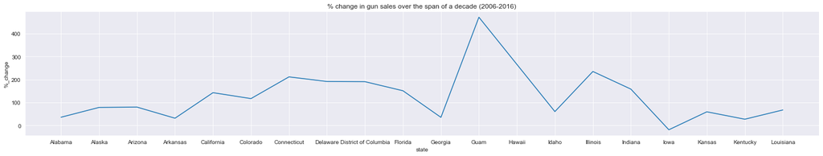

```python
#combined_df['%_change'].head(10).plot.line(x='state', y='%_change',title='', figsize=(20,4))
fig, ax = plt.subplots(1, figsize=(25,4))

ax = sns.lineplot(data=combined_df.head(20), x='state', y='%_change',)
plt.title('% change in gun sales over the span of a decade (2006-2016)')
```

# Which census data variables are most associated with gun sales data?

*To answer this question, I proceed merge the dataframes*

```python
# reading in the census data
df1 = pd.read_csv('df_census_cleaned_v2.csv')
df1.head()
```

|  | state | pop_2016 | female_pct | white_pct | black_pct | asian_pct | pe_hh | pe_whi | adults_below_65 | high_school_grad_higher | bsc_higher | median_hu | median_gross_rent | poverty_pct | median_hh_income | per_cap_inc | firms |
| --- | --- | --- | --- | --- | --- | --- | --- | --- | --- | --- | --- | --- | --- | --- | --- | --- | --- |
| 0 | Alabama | 4863300.0 | 51.6 | 69.3 | 26.8 | 1.4 | 2.55 | 10.7 | 61.3 | 84.3 | 23.5 | 125500.0 | 717.0 | 17.1 | 43623.0 | 24091.0 | 374153.0 |
| 1 | Alaska | 741894.0 | 47.7 | 66.1 | 3.8 | 6.3 | 2.81 | 15.5 | 64.4 | 92.1 | 28.0 | 250000.0 | 1146.0 | 9.9 | 72515.0 | 33413.0 | 68032.0 |
| 2 | Arizona | 6931071.0 | 50.3 | 83.3 | 4.9 | 3.4 | 2.69 | 11.9 | 59.6 | 86.0 | 27.5 | 167500.0 | 913.0 | 16.4 | 50255.0 | 25848.0 | 499926.0 |
| 3 | Arkansas | 2988248.0 | 50.9 | 79.4 | 15.7 | 1.6 | 2.53 | 9.3 | 60.1 | 84.8 | 21.1 | 111400.0 | 677.0 | 17.2 | 41371.0 | 22798.0 | 231959.0 |
| 4 | California | 39250017.0 | 50.3 | 72.7 | 6.5 | 14.8 | 2.96 | 8.3 | 63.2 | 81.8 | 31.4 | 385500.0 | 1255.0 | 14.3 | 61818.0 | 30318.0 | 3548449.0 |

## Data Dictionary

| s/n | Variable | Description |
| --- | --- | --- |
| 0 | state | Each of the 50 states of the contiguous U.S. |
| 1 | pop_2016 | Population estimates by July 1, 2016 |
| 2 | female_pct | Female persons, percent, by July 1, 2016 |
| 3 | white_pct | White alone, percent, by July 1, 2016 |
| 4 | black_pct | Black or African American alone, percent by July 1, 2016 |
| 5 | asian_pct | Asian alone, percent, July 1, 2016 |
| 6 | pe_hh | Persons per household, 2011-2015 |
| 7 | pe_whi | Persons without health insurance, under age 65 years, percent |
| 8 | adults_below_65 | adults older than 18, younger than 65, percent, 2016 |
| 9 | high_school_grad_higher | High school graduate or higher, percent of persons age 25 years+, 2011-2015 |
| 10 | bsc_higher | Bachelor\'s degree or higher, percent of persons age 25 years+, 2011-2015 |
| 11 | median_hu | Median value of owner-occupied housing units, 2011-2015 |
| 12 | median_gross_rent | Median gross rent, 2011-2015 |
| 13 | poverty_pct | Persons in poverty, percent |
| 14 | median_hh_income | Median household income (in 2015 dollars), 2011-2015 |
| 15 | per_cap_inc | Per capita income in past 12 months (in 2015 dollars), 2011-2015 |
| 16 | firms | All firms, 2012 |

```python
# reading in the gun data
df2 = pd.read_csv('df2_2016.csv', index_col=0)
df2.head()
```

|  | state | handgun | long_gun | multiple | month |
| --- | --- | --- | --- | --- | --- |
| 0 | Alabama | 15106.3 | 19270.9 | 1066 | 12 |
| 1 | Alaska | 4495.7 | 4067.8 | 382 | 12 |
| 2 | Arizona | 19826.4 | 15163.5 | 1406 | 12 |
| 3 | Arkansas | 10111.2 | 14776.3 | 770 | 12 |
| 4 | California | 70013.9 | 102546.4 | 0 | 12 |

## Data Dictionary

| s/n | Variable | Description |
| --- | --- | --- |
| 0 | state | Each of the 55 states and territories of the .U.S. |
| 1 | handgun | handgun checks, transformed into sales by a factor of 1.1 |
| 2 | long_gun | long-gun checks, transformed into sales by a factor of 1.1 |
| 3 | multiple | multiple gun checks, transformed into sales by a factor of 2 |
| 4 | month | months of 2016 |

```python
# number of unique states in census dataframe
df1.state.nunique()
```

```
50
```

```python
# number of unique states in gun sales dataframe
df2.state.nunique()
```

```
55
```

```python
# getting the uncommon territories in both datasets
s1 = df1.state
s2 = df2.state.unique()
common_states = s1[s1.isin(s2)]

s3 = df2.query("state not in @common_states")
s3.loc[:, 'state'].unique()
```

```
array(['District of Columbia', 'Guam', 'Mariana Islands', 'Puerto Rico',
       'Virgin Islands'], dtype=object)
```

These territories are part of the commonwealth of the United States but are not part of the mainland.

```python
# creating 'total' column
df2['total'] = df2['handgun'] + df2['long_gun'] + df2['multiple']
```

```python
# aggregating df2 on the gun sales columns
df2_agg = df2.groupby('state')[['handgun','long_gun','multiple', 'total']].sum()
df2_agg
```

| state | handgun | long_gun | multiple | total |
| --- | --- | --- | --- | --- |
| Alabama | 168435.3 | 134159.3 | 13090 | 315684.6 |
| Alaska | 41240.1 | 40575.7 | 4632 | 86447.8 |
| Arizona | 183462.4 | 119886.8 | 15816 | 319165.2 |
| Arkansas | 88268.4 | 90332.0 | 8800 | 187400.4 |
| California | 616390.5 | 610005.0 | 0 | 1226395.5 |
| Colorado | 266752.2 | 198028.6 | 28586 | 493366.8 |
| Connecticut | 134612.5 | 48194.3 | 0 | 182806.8 |
| Delaware | 28131.4 | 23920.6 | 2068 | 54120.0 |
| District of Columbia | 742.5 | 52.8 | 16 | 811.3 |
| Florida | 728538.8 | 347855.2 | 50284 | 1126678.0 |
| Georgia | 214280.0 | 141104.7 | 14956 | 370340.7 |
| Guam | 1373.9 | 726.0 | 134 | 2233.9 |
| Hawaii | 0.0 | 0.0 | 0 | 0.0 |
| Idaho | 51175.3 | 61150.1 | 4812 | 117137.4 |
| Illinois | 387652.1 | 194980.5 | 24266 | 606898.6 |
| Indiana | 306000.2 | 194939.8 | 18164 | 519104.0 |
| Iowa | 3069.0 | 38779.4 | 140 | 41988.4 |
| Kansas | 89227.6 | 81122.8 | 8542 | 178892.4 |
| Kentucky | 154793.1 | 119933.0 | 13886 | 288612.1 |
| Louisiana | 188746.8 | 153034.2 | 17218 | 358999.0 |
| Maine | 53729.5 | 51458.0 | 4916 | 110103.5 |
| Mariana Islands | 0.0 | 17.6 | 0 | 17.6 |
| Maryland | 57535.5 | 79081.2 | 674 | 137290.7 |
| Massachusetts | 83574.7 | 46124.1 | 4960 | 134658.8 |
| Michigan | 181365.8 | 141997.9 | 5630 | 328993.7 |
| Minnesota | 147358.2 | 157897.3 | 10092 | 315347.5 |
| Mississippi | 130955.0 | 102104.2 | 10526 | 243585.2 |
| Missouri | 302229.4 | 222978.8 | 25506 | 550714.2 |
| Montana | 41301.7 | 62517.4 | 5356 | 109175.1 |
| Nebraska | 1888.7 | 29143.4 | 164 | 31196.1 |
| Nevada | 72773.8 | 41915.5 | 7446 | 122135.3 |
| New Hampshire | 75381.9 | 49149.1 | 110 | 124641.0 |
| New Jersey | 77273.9 | 54008.9 | 0 | 131282.8 |
| New Mexico | 76377.4 | 61230.4 | 7464 | 145071.8 |
| New York | 146613.5 | 217437.0 | 4932 | 368982.5 |
| North Carolina | 18254.5 | 194610.9 | 5624 | 218489.4 |
| North Dakota | 21972.5 | 37414.3 | 1944 | 61330.8 |
| Ohio | 434027.0 | 268359.3 | 32666 | 735052.3 |
| Oklahoma | 182799.1 | 143565.4 | 21322 | 347686.5 |
| Oregon | 196587.6 | 157331.9 | 0 | 353919.5 |
| Pennsylvania | 706455.2 | 173955.1 | 0 | 880410.3 |
| Puerto Rico | 14056.9 | 2657.6 | 550 | 17264.5 |
| Rhode Island | 15688.2 | 11224.4 | 3998 | 30910.6 |
| South Carolina | 145720.3 | 96154.3 | 8980 | 250854.6 |
| South Dakota | 40172.0 | 54474.2 | 4368 | 99014.2 |
| Tennessee | 351085.9 | 231177.1 | 22184 | 604447.0 |
| Texas | 701223.6 | 529769.9 | 66204 | 1297197.5 |
| Utah | 52141.1 | 59546.3 | 2382 | 114069.4 |
| Vermont | 20152.0 | 20738.3 | 1770 | 42660.3 |
| Virgin Islands | 292.6 | 62.7 | 10 | 365.3 |
| Virginia | 325559.3 | 230972.5 | 0 | 556531.8 |
| Washington | 235516.6 | 166131.9 | 16056 | 417704.5 |
| West Virginia | 101336.4 | 89215.5 | 10566 | 201117.9 |
| Wisconsin | 204930.0 | 175762.4 | 1046 | 381738.4 |
| Wyoming | 24825.9 | 28396.5 | 2590 | 55812.4 |

I will do a merge on df1's state column

```python
merged_df = df2_agg.merge(df1, on='state', how='inner')
merged_df.head(20)
```

|  | state | handgun | long_gun | multiple | total | pop_2016 | female_pct | white_pct | black_pct | asian_pct | ... | pe_whi | adults_below_65 | high_school_grad_higher | bsc_higher | median_hu | median_gross_rent | poverty_pct | median_hh_income | per_cap_inc | firms |
| --- | --- | --- | --- | --- | --- | --- | --- | --- | --- | --- | --- | --- | --- | --- | --- | --- | --- | --- | --- | --- | --- |
| 0 | Alabama | 168435.3 | 134159.3 | 13090 | 315684.6 | 4863300.0 | 51.6 | 69.3 | 26.8 | 1.4 | ... | 10.7 | 61.3 | 84.3 | 23.5 | 125500.0 | 717.0 | 17.1 | 43623.0 | 24091.0 | 374153.0 |
| 1 | Alaska | 41240.1 | 40575.7 | 4632 | 86447.8 | 741894.0 | 47.7 | 66.1 | 3.8 | 6.3 | ... | 15.5 | 64.4 | 92.1 | 28.0 | 250000.0 | 1146.0 | 9.9 | 72515.0 | 33413.0 | 68032.0 |
| 2 | Arizona | 183462.4 | 119886.8 | 15816 | 319165.2 | 6931071.0 | 50.3 | 83.3 | 4.9 | 3.4 | ... | 11.9 | 59.6 | 86.0 | 27.5 | 167500.0 | 913.0 | 16.4 | 50255.0 | 25848.0 | 499926.0 |
| 3 | Arkansas | 88268.4 | 90332.0 | 8800 | 187400.4 | 2988248.0 | 50.9 | 79.4 | 15.7 | 1.6 | ... | 9.3 | 60.1 | 84.8 | 21.1 | 111400.0 | 677.0 | 17.2 | 41371.0 | 22798.0 | 231959.0 |
| 4 | California | 616390.5 | 610005.0 | 0 | 1226395.5 | 39250017.0 | 50.3 | 72.7 | 6.5 | 14.8 | ... | 8.3 | 63.2 | 81.8 | 31.4 | 385500.0 | 1255.0 | 14.3 | 61818.0 | 30318.0 | 3548449.0 |
| 5 | Colorado | 266752.2 | 198028.6 | 28586 | 493366.8 | 5540545.0 | 49.7 | 87.5 | 4.5 | 3.3 | ... | 8.6 | 63.8 | 90.7 | 38.1 | 247800.0 | 1002.0 | 11.0 | 60629.0 | 32217.0 | 547352.0 |
| 6 | Connecticut | 134612.5 | 48194.3 | 0 | 182806.8 | 3576452.0 | 51.2 | 80.6 | 11.8 | 4.7 | ... | 5.7 | 62.8 | 89.9 | 37.6 | 270500.0 | 1075.0 | 9.8 | 70331.0 | 38803.0 | 326693.0 |
| 7 | Delaware | 28131.4 | 23920.6 | 2068 | 54120.0 | 952065.0 | 51.6 | 70.1 | 22.6 | 4.0 | ... | 6.6 | 61.0 | 88.4 | 30.0 | 231500.0 | 1018.0 | 11.7 | 60509.0 | 30554.0 | 73418.0 |
| 8 | Florida | 728538.8 | 347855.2 | 50284 | 1126678.0 | 20612439.0 | 51.1 | 77.6 | 16.8 | 2.9 | ... | 15.3 | 60.0 | 86.9 | 27.3 | 159000.0 | 1002.0 | 14.7 | 47507.0 | 26829.0 | 2100187.0 |
| 9 | Georgia | 214280.0 | 141104.7 | 14956 | 370340.7 | 10310371.0 | 51.3 | 61.2 | 32.0 | 4.1 | ... | 14.8 | 62.5 | 85.4 | 28.8 | 148100.0 | 879.0 | 16.0 | 49620.0 | 25737.0 | 929864.0 |
| 10 | Hawaii | 0.0 | 0.0 | 0 | 0.0 | 1428557.0 | 49.8 | 25.8 | 2.2 | 37.7 | ... | 4.2 | 61.3 | 91.0 | 30.8 | 515300.0 | 1438.0 | 9.3 | 69515.0 | 29822.0 | 118454.0 |
| 11 | Idaho | 51175.3 | 61150.1 | 4812 | 117137.4 | 1683140.0 | 49.9 | 93.3 | 0.8 | 1.5 | ... | 11.8 | 58.9 | 89.5 | 25.9 | 162900.0 | 743.0 | 14.4 | 47583.0 | 23399.0 | 146642.0 |
| 12 | Illinois | 387652.1 | 194980.5 | 24266 | 606898.6 | 12801539.0 | 50.9 | 77.2 | 14.7 | 5.5 | ... | 7.4 | 62.5 | 87.9 | 32.3 | 173800.0 | 907.0 | 13.0 | 57574.0 | 30494.0 | 1135017.0 |
| 13 | Indiana | 306000.2 | 194939.8 | 18164 | 519104.0 | 6633053.0 | 50.7 | 85.6 | 9.7 | 2.2 | ... | 9.4 | 61.3 | 87.8 | 24.1 | 124200.0 | 745.0 | 14.1 | 49255.0 | 25346.0 | 479059.0 |
| 14 | Iowa | 3069.0 | 38779.4 | 140 | 41988.4 | 3134693.0 | 50.3 | 91.4 | 3.7 | 2.5 | ... | 5.0 | 60.3 | 91.5 | 26.7 | 129200.0 | 697.0 | 11.8 | 53183.0 | 27950.0 | 259121.0 |
| 15 | Kansas | 89227.6 | 81122.8 | 8542 | 178892.4 | 2907289.0 | 50.2 | 86.6 | 6.2 | 3.0 | ... | 10.1 | 60.4 | 90.2 | 31.0 | 132000.0 | 757.0 | 12.1 | 52205.0 | 27706.0 | 239118.0 |
| 16 | Kentucky | 154793.1 | 119933.0 | 13886 | 288612.1 | 4436974.0 | 50.7 | 88.0 | 8.3 | 1.5 | ... | 6.0 | 61.6 | 84.2 | 22.3 | 123200.0 | 675.0 | 18.5 | 43740.0 | 24063.0 | 331546.0 |
| 17 | Louisiana | 188746.8 | 153034.2 | 17218 | 358999.0 | 4681666.0 | 51.1 | 63.2 | 32.6 | 1.8 | ... | 11.9 | 61.8 | 83.4 | 22.5 | 144100.0 | 788.0 | 20.2 | 45047.0 | 24981.0 | 414291.0 |
| 18 | Maine | 53729.5 | 51458.0 | 4916 | 110103.5 | 1331479.0 | 51.0 | 94.8 | 1.5 | 1.2 | ... | 9.9 | 61.5 | 91.6 | 29.0 | 173800.0 | 777.0 | 12.5 | 49331.0 | 27655.0 | 139570.0 |
| 19 | Maryland | 57535.5 | 79081.2 | 674 | 137290.7 | 6016447.0 | 51.6 | 59.3 | 30.7 | 6.6 | ... | 7.0 | 63.0 | 89.4 | 37.9 | 286900.0 | 1230.0 | 9.7 | 74551.0 | 36897.0 | 531953.0 |

20 rows × 21 columns

```python
# checking for nans throughout the dataframe
merged_df.isnull().sum().sum()
```

```
0
```

```python
merged_df.info()
```

```
<class 'pandas.core.frame.DataFrame'>
Int64Index: 50 entries, 0 to 49
Data columns (total 21 columns):
 #   Column                   Non-Null Count  Dtype
---  ------                   --------------  -----
 0   state                    50 non-null     object
 1   handgun                  50 non-null     float64
 2   long_gun                 50 non-null     float64
 3   multiple                 50 non-null     int64
 4   total                    50 non-null     float64
 5   pop_2016                 50 non-null     float64
 6   female_pct               50 non-null     float64
 7   white_pct                50 non-null     float64
 8   black_pct                50 non-null     float64
 9   asian_pct                50 non-null     float64
 10  pe_hh                    50 non-null     float64
 11  pe_whi                   50 non-null     float64
 12  adults_below_65          50 non-null     float64
 13  high_school_grad_higher  50 non-null     float64
 14  bsc_higher               50 non-null     float64
 15  median_hu                50 non-null     float64
 16  median_gross_rent        50 non-null     float64
 17  poverty_pct              50 non-null     float64
 18  median_hh_income         50 non-null     float64
 19  per_cap_inc              50 non-null     float64
 20  firms                    50 non-null     float64
dtypes: float64(19), int64(1), object(1)
memory usage: 8.6+ KB
```

```python
merged_df.shape
```

```
(50, 21)
```

```python
# saving for later
merged_df.to_csv('merged_cleaned_data.csv', index=False)
```

# Exploratory Data Analysis(UNIVARIATE)

*(Merged dataframe)*

### Let's explore the first 5 columns, representing the gun sales data

```python
merged_df = pd.read_csv('merged_cleaned_data.csv')
merged_df.head()
```

|  | state | handgun | long_gun | multiple | total | pop_2016 | female_pct | white_pct | black_pct | asian_pct | ... | pe_whi | adults_below_65 | high_school_grad_higher | bsc_higher | median_hu | median_gross_rent | poverty_pct | median_hh_income | per_cap_inc | firms |
| --- | --- | --- | --- | --- | --- | --- | --- | --- | --- | --- | --- | --- | --- | --- | --- | --- | --- | --- | --- | --- | --- |
| 0 | Alabama | 168435.3 | 134159.3 | 13090 | 315684.6 | 4863300.0 | 51.6 | 69.3 | 26.8 | 1.4 | ... | 10.7 | 61.3 | 84.3 | 23.5 | 125500.0 | 717.0 | 17.1 | 43623.0 | 24091.0 | 374153.0 |
| 1 | Alaska | 41240.1 | 40575.7 | 4632 | 86447.8 | 741894.0 | 47.7 | 66.1 | 3.8 | 6.3 | ... | 15.5 | 64.4 | 92.1 | 28.0 | 250000.0 | 1146.0 | 9.9 | 72515.0 | 33413.0 | 68032.0 |
| 2 | Arizona | 183462.4 | 119886.8 | 15816 | 319165.2 | 6931071.0 | 50.3 | 83.3 | 4.9 | 3.4 | ... | 11.9 | 59.6 | 86.0 | 27.5 | 167500.0 | 913.0 | 16.4 | 50255.0 | 25848.0 | 499926.0 |
| 3 | Arkansas | 88268.4 | 90332.0 | 8800 | 187400.4 | 2988248.0 | 50.9 | 79.4 | 15.7 | 1.6 | ... | 9.3 | 60.1 | 84.8 | 21.1 | 111400.0 | 677.0 | 17.2 | 41371.0 | 22798.0 | 231959.0 |
| 4 | California | 616390.5 | 610005.0 | 0 | 1226395.5 | 39250017.0 | 50.3 | 72.7 | 6.5 | 14.8 | ... | 8.3 | 63.2 | 81.8 | 31.4 | 385500.0 | 1255.0 | 14.3 | 61818.0 | 30318.0 | 3548449.0 |

5 rows × 21 columns

```python
merged_df.info()
```

```
<class 'pandas.core.frame.DataFrame'>
RangeIndex: 50 entries, 0 to 49
Data columns (total 21 columns):
 #   Column                   Non-Null Count  Dtype
---  ------                   --------------  -----
 0   state                    50 non-null     object
 1   handgun                  50 non-null     float64
 2   long_gun                 50 non-null     float64
 3   multiple                 50 non-null     int64
 4   total                    50 non-null     float64
 5   pop_2016                 50 non-null     float64
 6   female_pct               50 non-null     float64
 7   white_pct                50 non-null     float64
 8   black_pct                50 non-null     float64
 9   asian_pct                50 non-null     float64
 10  pe_hh                    50 non-null     float64
 11  pe_whi                   50 non-null     float64
 12  adults_below_65          50 non-null     float64
 13  high_school_grad_higher  50 non-null     float64
 14  bsc_higher               50 non-null     float64
 15  median_hu                50 non-null     float64
 16  median_gross_rent        50 non-null     float64
 17  poverty_pct              50 non-null     float64
 18  median_hh_income         50 non-null     float64
 19  per_cap_inc              50 non-null     float64
 20  firms                    50 non-null     float64
dtypes: float64(19), int64(1), object(1)
memory usage: 8.3+ KB
```

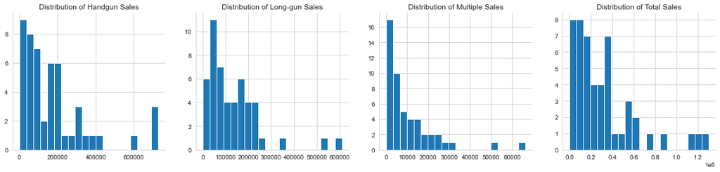

```python
# plotting
sns.set_style('whitegrid')
fig, (ax1, ax2, ax3, ax4) = plt.subplots(1, 4, figsize=(20,4))


merged_df.handgun.hist(bins=20, ax=ax1)
merged_df.long_gun.hist(bins=20, ax=ax2)
merged_df.multiple.hist(bins=20, ax=ax3)
merged_df.total.hist(bins=20, ax=ax4)

ax1.set(title='Distribution of Handgun Sales')
ax2.set(title='Distribution of Long-gun Sales')
ax3.set(title='Distribution of Multiple Sales')
ax4.set(title='Distribution of Total Sales')

sns.despine(right=True)
sns.despine(offset=0, trim=False)
```

```python
# summary statistics
merged_df[['handgun', 'long_gun', 'multiple', 'total']].describe().T
```

|  | count | mean | std | min | 25% | 50% | 75% | max |
| --- | --- | --- | --- | --- | --- | --- | --- | --- |
| handgun | 50.0 | 177551.638 | 185945.395696 | 0.0 | 51416.750 | 132783.75 | 211942.500 | 728538.8 |
| long_gun | 50.0 | 131676.908 | 118931.726762 | 0.0 | 49726.325 | 99129.25 | 175310.575 | 610005.0 |
| multiple | 50.0 | 10294.720 | 13047.318153 | 0.0 | 1813.500 | 5490.00 | 14688.500 | 66204.0 |
| total | 50.0 | 319523.266 | 302625.048243 | 0.0 | 114836.400 | 231037.30 | 378888.975 | 1297197.5 |

As expected with data regarding sales, the data is heavily right-skewed; with most of gun sales on the low end, evidenced by the mean being greater than the median.

### Let's explore the next 5 columns, representing the population % by race

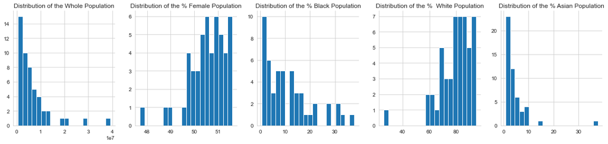

```python
sns.set_style('whitegrid')
fig, (ax1, ax2, ax3, ax4, ax5) = plt.subplots(1, 5, figsize=(20,4))


merged_df.pop_2016.hist(bins=20, ax=ax1)
merged_df.female_pct.hist(bins=20, ax=ax2)
merged_df.black_pct.hist(bins=20, ax=ax3)
merged_df.white_pct.hist(bins=20, ax=ax4)
merged_df.asian_pct.hist(bins=20, ax=ax5)

ax1.set(title='Distribution of the Whole Population')
ax2.set(title='Distribution of the % Female Population')
ax3.set(title='Distribution of the % Black Population')
ax4.set(title='Distribution of the %  White Population')
ax5.set(title='Distribution of the % Asian Population')

sns.despine(right=True)
sns.despine(offset=0, trim=False)
```

The black and asian race are the minorities looking at the range of their percentages

### Let's explore the next 5 columns, representing levels of education and persons per household and persons without health insurance

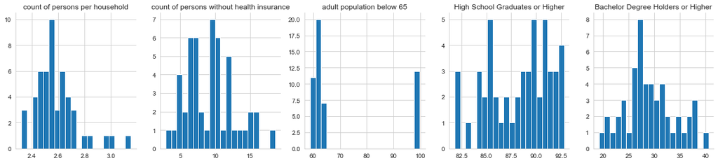

```python
sns.set_style('whitegrid')
fig, (ax1, ax2, ax3, ax4, ax5) = plt.subplots(1, 5, figsize=(20,4))


merged_df. pe_hh.hist(bins=20, ax=ax1)
merged_df.pe_whi.hist(bins=20, ax=ax2)
merged_df.adults_below_65.hist(bins=20, ax=ax3)
merged_df.high_school_grad_higher.hist(bins=20, ax=ax4)
merged_df.bsc_higher.hist(bins=20, ax=ax5)

ax1.set(title='count of persons per household')
ax2.set(title='count of persons without health insurance')
ax3.set(title='adult population below 65')
ax4.set(title='High School Graduates or Higher')
ax5.set(title='Bachelor Degree Holders or Higher')

sns.despine(right=True)
sns.despine(offset=0, trim=False)
```

Just a few % of the population are without health insurance and the population is highly educated

## Let's explore the next 6 columns, representing economic data

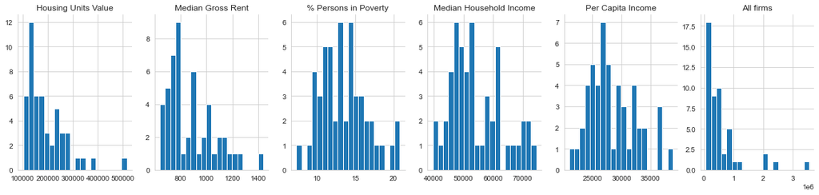

```python
sns.set_style('whitegrid')
fig, (ax1, ax2, ax3, ax4, ax5, ax6) = plt.subplots(1, 6, figsize=(20,4))


merged_df.median_hu.hist(bins=20, ax=ax1)
merged_df.median_gross_rent.hist(bins=20, ax=ax2)
merged_df.poverty_pct .hist(bins=20, ax=ax3)
merged_df.median_hh_income.hist(bins=20, ax=ax4)
merged_df.per_cap_inc.hist(bins=20, ax=ax5)
merged_df.firms.hist(bins=20, ax=ax6)

ax1.set(title='Housing Units Value')
ax2.set(title='Median Gross Rent')
ax3.set(title='% Persons in Poverty')
ax4.set(title='Median Household Income')
ax5.set(title='Per Capita Income')
ax6.set(title='All firms')

sns.despine(right=True)
sns.despine(offset=0, trim=False)
```

### Covariate Analysis

I want to create a new calculated column: `gun_sales_per_capita`, which would be derived from the division of total gun sales by state populations. This would provide a more appropriate baseline for the comparison of gun sales between states

```python
merged_df['gun_sales_per_capita'] = merged_df['total'] / merged_df['pop_2016']
```

```python
merged_df['gun_sales_per_capita'].describe()
```

```
count    50.000000
mean      0.060184
std       0.028694
min       0.000000
25%       0.038424
50%       0.063000
75%       0.081355
max       0.116523
Name: gun_sales_per_capita, dtype: float64
```

```python
# getting the correlations with gun per capita

merged_df.corrwith(other=merged_df['gun_sales_per_capita'])
```

```
handgun                    0.029506
long_gun                  -0.056207
multiple                   0.122681
total                      0.001330
pop_2016                  -0.335466
female_pct                -0.384595
white_pct                  0.382182
black_pct                 -0.223373
asian_pct                 -0.492825
pe_hh                     -0.386078
pe_whi                     0.275326
adults_below_65            0.103166
high_school_grad_higher    0.147886
bsc_higher                -0.356364
median_hu                 -0.408704
median_gross_rent         -0.462526
poverty_pct                0.169764
median_hh_income          -0.319988
per_cap_inc               -0.260645
firms                     -0.337613
gun_sales_per_capita       1.000000
dtype: float64
```

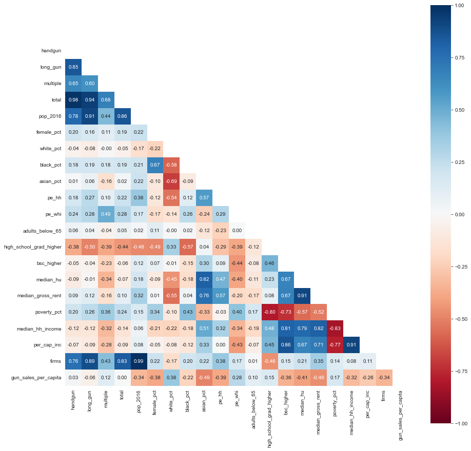

```python
# visualizing the correlations

fig, ax = plt.subplots(figsize=(15, 15))
corr = merged_df.corr()

mask = np.zeros_like(corr, dtype=bool)
mask[np.triu_indices_from(mask)] = True

sns.heatmap(corr, mask=mask, fmt=".2f", annot=True, ax=ax, cmap="RdBu", vmin=-1, vmax=1, square=True)
```

### Plotting the variables against `gun_sales_per_capita` to spot associations

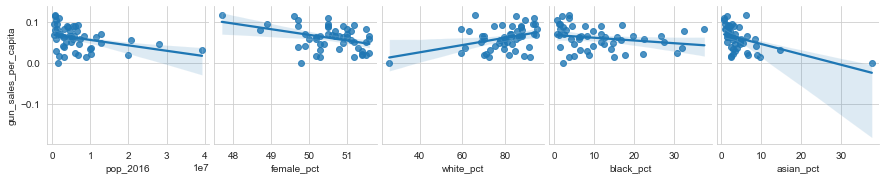

```python
sns.pairplot(merged_df, x_vars=['pop_2016', 'female_pct', 'white_pct', 'black_pct', 'asian_pct'], y_vars=['gun_sales_per_capita'], kind='reg')
```

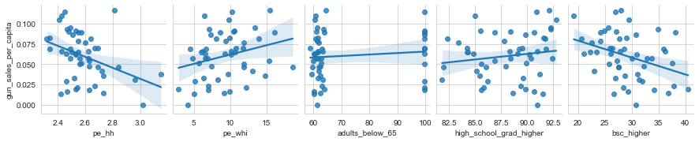

```python
sns.pairplot(merged_df, x_vars=['pe_hh', 'pe_whi','adults_below_65', 'high_school_grad_higher', 'bsc_higher'], y_vars=['gun_sales_per_capita'], kind='reg')
```

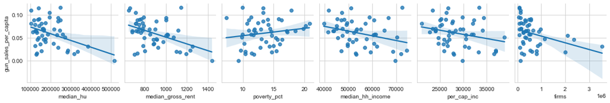

```python
sns.pairplot(merged_df, x_vars=['median_hu', 'median_gross_rent','poverty_pct', 'median_hh_income', 'per_cap_inc', 'firms'], y_vars=['gun_sales_per_capita'], kind='reg')
```

*Which census data is most associated with high gun sales per capita*

| Variable | Positive/Negative Correlation |
| --- | --- |
| persons per household (pe_hh) | negative |
| persons without health insurance (pe_whi) | positive |
| bachelor degree holder or higher (bsc_higher) | negative |
| median housing unit costs (median_hu) | negative |
| median gross rent | negative |

# Conclusions

Caveats!  
**The findings of these analysis are summarised below. These are tentative and do indicate any causal relationship between variables.**

> - *The most populous states in the United States in 2016 are California, Texas, Florida, New York and Illinois.*
> - *The least populous states are Wyoming, Vermont, Alaska, North Dakota and South Dakota.*
> - *States with the highest median household income in 2016 are Maryland, Alaska, New Jersey, Connecticut and Hawaii.*
> - *States with the lowest median household income in 2016 are Mississippi, Arkankas, West Virginia, Alabama, and Kentucky.*
> - *States with the highest black population in 2016 are Mississippi, Louisiana, Georgia, Maryland and South Carolina.*
> - *States with the lowest black population in 2016 are Montana, Idaho, Vermont, Wyoming and Utah.*

### 2006

> - *Long guns were sold the most in 2006 with about 5,268,550 units sold.*
> - *In 2006, handgun sales varied between 200 thousand and 300 thousand units throughout the year. However, long-gun sales started strongly at around 400 thousand units in January, started sinking in March till a year-low of just below 300 thousand units before dramatically shooting up to about 800 thousand units at the end of the year*
> - *The top 5 states in terms of gun sales are Texas, Pennsylvania, California, Florida and Ohio.*
> - *Among these states, only in Florida were handgun sales greater than long-gun sales.*
> - *All these states experience a remarkable dip in sales in the middle of the year.*

### 2015

> *9 years later in 2015, handguns became most bought gun types with a total of about 8 million units sold across all states in the U.S.*

> *The same trend of a dip in sales around the middle of the year and a sharp rise in purchases towards the end of the year persists.*

> *Texas remains the top state in terms of gun purchases.*

### 2016

> *A year later in 2016, total gun sales reached a little short of 16 million units. Handguns led the way at more than 8 million units.*

> *Gun sales started relatively high compared to the previous years. I note the double dip in sales with second dip occuring around September. This double dip was mostly prominent in Florida. Another trend of note is that long-gun sales almost superceded handgun sales country-wise in November.*